# Final Project

Kay Denmead, Leila Imani, Ethan Ni

2024-05-17

# Abstract

[output not shown]

# Introduction

Humanity’s presence has had and will continue to have a profound impact on the Earth and the ecological processes that define it. Human emissions of greenhouse gasses are drastically impacting habitats around the globe, disrupting ecosystems and threatening biodiversity. Because of the incredible magnitude of change we are putting on the earth, it is important that we fully understand the effects of anthropogenic change on our ecosystems. Building this understanding is the first step towards taking action to protect the life around us. The National Ecological Observatory Network (NEON) program is an NSF-funded project that aims to quantify the changing ecological processes across the United States. NEON provides open data that characterize plants, animals, soil, nutrients, freshwater, and the atmosphere.(“Overview NSF NEON Open Data to Understand Our Ecosystems” n.d.)

Caribou Creek Watershed is a NEON field site located in central Alaska, northeast of Fairbanks. The site contains a variety of ecosystems, including shrublands, wetlands, hardwood forests, and scattered permafrost. Alaska as a whole is very affected by climate change, experiencing a temperature increase of 2.5 degrees C since 1948. The soils at this site are affected by a cycle of ice thawing and freezing. This results in a phenomenon called cryoturbation, which is when soil gets mixed by freezing and thawing ground ice. [Driscoll et al. (2012)](“Overview NSF NEON Open Data to Understand Our Ecosystems” n.d.)

Myxococcta is a bacterial phylum which is notable for its “social lifestyle”, a trait that is unusual in prokaryotes. These bacteria can thrive in many different environments including soil rich in organic matter, rotting wood, animal dung, and marine environments (Saggu, Nath, and Kumar 2023)They have gliding motility and predatory behavior. They hunt in packs, using their gliding motility to swarm prey cells, feeding by secreting lytic enzymes (Waite et al. 2020). A recent study found that Myxococcota contains a photosynthesis gene cluster that encodes the enzymes necessary for bacteriochlorophyll biosynthesis, among other crucial enzymes. Phylogenetic analyses have indicated that this phylum has an ancient phototrophic history, playing a uniquely important role in ecosystems (Li et al. 2023). They measure between 50-500 µm and can be seen with the naked eye (Shimkets, Dworkin, and Reichenbach 2006)

Despite being known for more than 100 years, myxobacteria have only been closely studied for the last few decades because they produce unique bioactive secondary metabolites. For this reason, these bacteria are being considered as an important source of natural products for drug discovery. For example, epothilones, isolated from Sorangium sp., are anti-tumor drugs that target microtubules and can be effective against taxol-resistant cancers (Mulzer et al. 2008). Further exploring the diversity of this phylum can contribute to future research with biotechnology applications.

# Methods

In constructing figures and comparing them, a more cohesive and comprehensive analysis of these variable relationships and how NEON site ecological makeup and bacterial preferences interplay created a varied and complex relationship within the dataset. As for the protocol used to obtain data at the NEON sites, soil samples are collected from 47 sites across the country each year. When collected, several types of data are collected, including measuring soil type, temperature, habitat type, etc. Using several different R packages, this data was sorted and visualized to determine the answers to several questions related to the Myxococcota phylum and the Caribou Creek NEON site.

In regards to Myxococcota, different R packages, data visualization, and sorting were utilized to determine the properties of Myxococcota when compared to other Phyla - particularly abundance, presences at NEON sites and ecosystem subtypes, preferences in soil pH, elevation, soil temperature, and relationships between those variables.

The NEON site in question, Caribou Creek, is an Alaskan site. In the use of different R packages, data visualization, and sorting methods, the relationship between the number and abundance of Phyla at the site, sample quality, soil pH, elevation, soil temperature, and how these variables compare to the other NEON sites in the available data set were examined.

# Results

## Loading Libraries

```r
if (!requireNamespace("BiocManager", quietly = TRUE))
  install.packages("BiocManager")
BiocManager::install("ggtreeExtra")
BiocManager::install("ggtree")
library(tidyverse)
```

```r
library(knitr)
library(DT)
library(plotly)
library(treeio)
library(TDbook)
library(ggimage)
library(rphylopic)
library(tidytree)
library(ape)
library(phytools)
library(TreeTools)
library(ggstar)
library(ggnewscale)
library(ggtreeExtra)
library(ggtree)
```

## Tree Information

```r
tree_arc <- read.tree("data/NEON/gtdbtk.ar53.decorated.tree")
tree_bac <- read.tree("data/NEON/gtdbtk.bac120.decorated.tree")
```

```r
tree_bac_preorder <- Preorder(tree_bac)
tree_Myxococcota <- Subtree(tree_bac_preorder, 2984)
```

## Loading in NEON data

```r
NEON_MAGs <- read_csv("data/NEON/GOLD_Study_ID_Gs0161344_NEON_edArchaea.csv") %>%
  select(-c(`GOLD Study ID`, `Bin Methods`, `Created By`, `Date Added`)) %>%
  mutate("Assembly Type" = case_when(`Genome Name` == "NEON combined assembly" ~ `Genome Name`, TRUE ~ "Individual")) %>%
  mutate_at("Assembly Type", str_replace, "NEON combined assembly", "Combined") %>%
  separate(`GTDB-Tk Taxonomy Lineage`, c("Domain", "Phylum", "Class", "Order", "Family", "Genus"), "; ", remove = FALSE) %>%
  mutate_at("Genome Name", str_replace, "Terrestrial soil microbial communities from ", "") %>%
  separate(`Genome Name`, c("Site","Sample Name"), " - ") %>%
  mutate_at("Sample Name", str_replace, "-comp-1", "") %>%
  separate(`Sample Name`, c("Site ID","subplot.layer.date"), "_", remove = FALSE,) %>%
  separate(`subplot.layer.date`, c("Subplot", "Layer", "Date"), "-")
NEON_metagenomes <- read_tsv("data/NEON/exported_img_data_Gs0161344_NEON.tsv") %>%
  rename(`Genome Name` = `Genome Name / Sample Name`) %>%
  filter(str_detect(`Genome Name`, 're-annotation', negate = T)) %>%
  filter(str_detect(`Genome Name`, 'WREF plot', negate = T))
NEON_metagenomes <- NEON_metagenomes %>%
  mutate_at("Genome Name", str_replace, "Terrestrial soil microbial communities from ", "") %>%
  separate(`Genome Name`, c("Site","Sample Name"), " - ") %>%
  mutate_at("Sample Name", str_replace, "-comp-1", "") %>%
  separate(`Sample Name`, c("Site ID","subplot.layer.date"), "_", remove = FALSE,) %>%
  separate(`subplot.layer.date`, c("Subplot", "Layer", "Date"), "-")
NEON_chemistry <- read_tsv("data/NEON/neon_plot_soilChem1_metadata.tsv") %>%
  mutate_at("genomicsSampleID", str_replace, "-COMP", "")
kable(NEON_chemistry_description <- read_tsv("data/NEON/neon_soilChem1_metadata_descriptions.tsv"))
```

| fieldName | description | dataType | units |
| --- | --- | --- | --- |
| siteID | NEON site code | string | NA |
| plotID | Plot identifier (NEON site code_XXX) | string | NA |
| sampleID | Identifier for sample | string | NA |
| horizon | Organic or mineral soil | string | NA |
| genomicsSampleID | Identifier for a genomics sample | string | NA |
| d15N | Measure of the ratio of 15N:14N in a sample, relative to atmospheric N2 | real | permill |
| organicd13C | Measure of the ratio of 13C:12C in soil organic carbon, relative to Vienna Pee Dee Belemnite | real | permill |
| nitrogenPercent | Percent nitrogen in a sample on a dry weight basis | real | percent |
| organicCPercent | Percent organic carbon in a sample on a dry weight basis | real | percent |
| CNratio | Ratio of carbon to nitrogen concentration in a sample on a dry weight basis | real | NA |
| nlcdClass | National Land Cover Database Vegetation Type Name | string | NA |
| subplotID | Identifier for the NEON subplot | string | NA |
| coreCoordinateX | x location of the soil core relative to the SW corner | real | meter |
| coreCoordinateY | y location of the soil core relative to the SW corner | real | meter |
| decimalLatitude | The geographic latitude (in decimal degrees, WGS84) of the geographic center of the reference area | real | decimalDegree |
| decimalLongitude | The geographic longitude (in decimal degrees, WGS84) of the geographic center of the reference area | real | decimalDegree |
| elevation | Elevation (in meters) above sea level | real | meter |
| sampleTiming | Timing of the sampling event with regard to the field season | string | NA |
| soilTemp | In-situ temperature of soil at approximately 10 cm depth | real | degree |
| sampleTopDepth | Depth below the soil surface of the top of a soil sample | real | centimeter |
| sampleBottomDepth | Depth below the soil surface of the bottom of a soil sample | real | centimeter |
| soilInWaterpH | pH value of soil measured in water solution | real | pH |
| soilInCaClpH | pH value of soil measured in calcium chloride solution | real | pH |

## Creating Dataframes

```r
NEON_MAGs_metagenomes_chemistry <- NEON_MAGs %>%
  left_join(NEON_metagenomes, by = "Sample Name") %>%
  left_join(NEON_chemistry, by = c("Sample Name" = "genomicsSampleID"))
```

```r
combined_df <- left_join(NEON_chemistry, NEON_metagenomes, by = c("siteID" = "Site ID"))
NEON_MAGs_ind <- NEON_MAGs %>%
  filter(`Assembly Type` == "Individual")
```

```r
NEON_MAGs_co <- NEON_MAGs %>%
  filter(`Assembly Type` == "Combined")
```

```r
NEON_MAGs <- read_csv("data/NEON/GOLD_Study_ID_Gs0161344_NEON.csv")
NEON_MAGs_Ind <- NEON_MAGs %>%
  filter(`Genome Name` != "NEON combined assembly")
NEON_MAGs_Ind_tax <- NEON_MAGs_Ind %>%
  separate(`GTDB-Tk Taxonomy Lineage`, c("Domain", "Phylum", "Class", "Order", "Family", "Genus"), "; ", remove = FALSE)
```

```r
NEON_MAGs_Ind_tax_sample <- NEON_MAGs_Ind_tax %>%
  mutate_at("Genome Name", str_replace, "Terrestrial soil microbial communities from ", "") %>%
  separate(`Genome Name`, c("Site","Sample Name"), " - ") %>%
  mutate_at("Sample Name", str_replace, "-comp-1", "") %>%
  separate(`Sample Name`, c("Site ID","subplot.layer.date"), "_", remove = FALSE,) %>%
  separate(`subplot.layer.date`, c("Subplot", "Layer", "Date"), "-",)
```

```r
NEON_MAGs <- read_csv("data/NEON/GOLD_Study_ID_Gs0161344_NEON.csv") %>%
  select(-c(`GOLD Study ID`, `Bin Methods`, `Created By`, `Date Added`)) %>%
  mutate("Assembly Type" = case_when(`Genome Name` == "NEON combined assembly" ~ `Genome Name`, TRUE ~ "Individual")) %>%
  mutate_at("Assembly Type", str_replace, "NEON combined assembly", "Combined") %>%
  separate(`GTDB-Tk Taxonomy Lineage`, c("Domain", "Phylum", "Class", "Order", "Family", "Genus"), "; ", remove = FALSE) %>%
  mutate_at("Genome Name", str_replace, "Terrestrial soil microbial communities from ", "") %>%
  separate(`Genome Name`, c("Site","Sample Name"), " - ") %>%
  mutate_at("Sample Name", str_replace, "-comp-1", "") %>%
  separate(`Sample Name`, c("Site ID","subplot.layer.date"), "_", remove = FALSE,) %>%
  separate(`subplot.layer.date`, c("Subplot", "Layer", "Date"), "-")
NEON_MAGs_bact_ind <- NEON_MAGs %>%
  filter(Domain == "Bacteria") %>%
  filter(`Assembly Type` == "Individual")
```

```r
NEON_MAGs_Myxococcota <- NEON_MAGs_metagenomes_chemistry %>%
  filter(Phylum == "Myxococcota")
```

## Figures

### General Information

```r
datatable(NEON_MAGs_Ind_tax %>%
    count(Phylum, sort = TRUE))
```

|  | Phylum | n |
| --- | --- | --- |
| 1 | Actinobacteriota | 418 |
| 2 | Proteobacteria | 248 |
| 3 | Acidobacteriota | 181 |
| 4 | Verrucomicrobiota | 57 |
| 5 |  | 38 |
| 6 | Chloroflexota | 35 |
| 7 | Myxococcota | 29 |
| 8 | Bacteroidota | 22 |
| 9 | Gemmatimonadota | 16 |
| 10 | Methylomirabilota | 16 |

[output cut: 15 more lines]

```r
datatable(NEON_MAGs_Ind_tax_sample %>%
    count(Site, sort = TRUE))
```

|  | Site | n |
| --- | --- | --- |
| 1 | National Grasslands LBJ, Texas, USA | 197 |
| 2 | Toolik Field Station, Alaska, USA | 149 |
| 3 | Chase Lake Wetlands, North Dakota, USA | 132 |
| 4 | Wind River Experimental Forest, Washington, USA | 100 |
| 5 | Niwot Ridge, Colorado, USA | 88 |
| 6 | Lower Teakettle, Sierra National Forest, California, USA | 81 |
| 7 | Caribou Creek Watershed, Alaska, USA | 69 |
| 8 | Konza Prairie Bio Station, Kansas, USA | 69 |
| 9 | Great Basin, Onaqui, Utah, USA | 60 |
| 10 | Guanica State Forest and Biosphere Reserve, Puerto Rico | 54 |

[output cut: 3 more lines]

```r
datatable(NEON_MAGs_Ind_tax %>%
  filter(str_detect(`Genome Name`, 'Caribou Creek')) %>%
  count(Phylum))
```

|  | Phylum | n |
| --- | --- | --- |
| 1 | Acidobacteriota | 10 |
| 2 | Actinobacteriota | 17 |
| 3 | Bacteroidota | 1 |
| 4 | Cyanobacteria | 2 |
| 5 | Eremiobacterota | 2 |
| 6 | Firmicutes | 1 |
| 7 | Planctomycetota | 1 |
| 8 | Proteobacteria | 30 |
| 9 | Verrucomicrobiota | 5 |

```r
datatable(NEON_MAGs_Ind_tax %>%
  filter(str_detect(`Phylum`, 'Myxococcota')) %>%
  count(`Genome Name`))
```

|  | Genome Name | n |
| --- | --- | --- |
| 1 | Terrestrial soil microbial communities from Chase Lake Wetlands, North Dakota, USA - WOOD_001-M-20210714-comp-1 | 1 |
| 2 | Terrestrial soil microbial communities from Chase Lake Wetlands, North Dakota, USA - WOOD_024-O-20210714-comp-1 | 3 |
| 3 | Terrestrial soil microbial communities from Healy, Denali National Park, Alaska, USA - HEAL_048-M-20210622-comp-1 | 1 |
| 4 | Terrestrial soil microbial communities from Konza Prairie Bio Station, Kansas, USA - KONZ_042-M-20210720-comp-1 | 1 |
| 5 | Terrestrial soil microbial communities from Lower Teakettle, Sierra National Forest, California, USA - TEAK_002-O-20210720-comp-1 | 2 |
| 6 | Terrestrial soil microbial communities from Lower Teakettle, Sierra National Forest, California, USA - TEAK_005-O-20210728-comp-1 | 2 |
| 7 | Terrestrial soil microbial communities from National Grasslands LBJ, Texas, USA - CLBJ_003-M-20210506-comp-1 | 2 |
| 8 | Terrestrial soil microbial communities from National Grasslands LBJ, Texas, USA - CLBJ_033-M-20210505-comp-1 | 1 |
| 9 | Terrestrial soil microbial communities from Niwot Ridge, Colorado, USA - NIWO_003-M-20210727-comp-1 | 2 |
| 10 | Terrestrial soil microbial communities from Niwot Ridge, Colorado, USA - NIWO_004-O-20210726-comp-1 | 1 |

[output cut: 10 more lines]

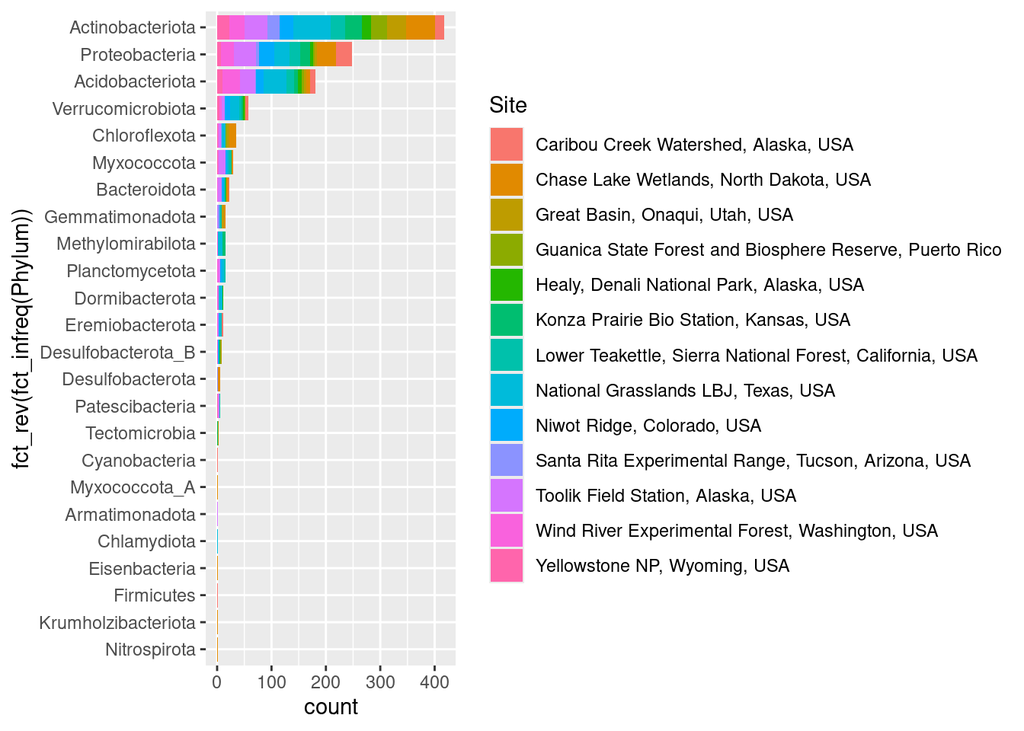

```r
NEON_MAGs_bact_ind %>%
ggplot(aes(x = fct_rev(fct_infreq(Phylum)), fill = Site)) +
  geom_bar() +
  coord_flip()
```

### Myxococcota

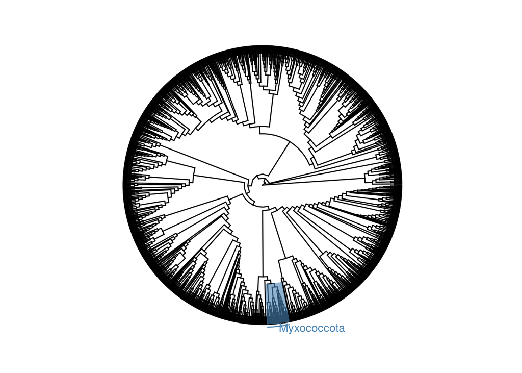

```r
ggtree(tree_bac, layout="circular", branch.length="none") +
    geom_hilight(node=2984, fill="steelblue", alpha=.6) +
    geom_cladelab(node=2984, label="Myxococcota", align=TRUE,
                  offset = 0, textcolor='steelblue', barcolor='steelblue')
```

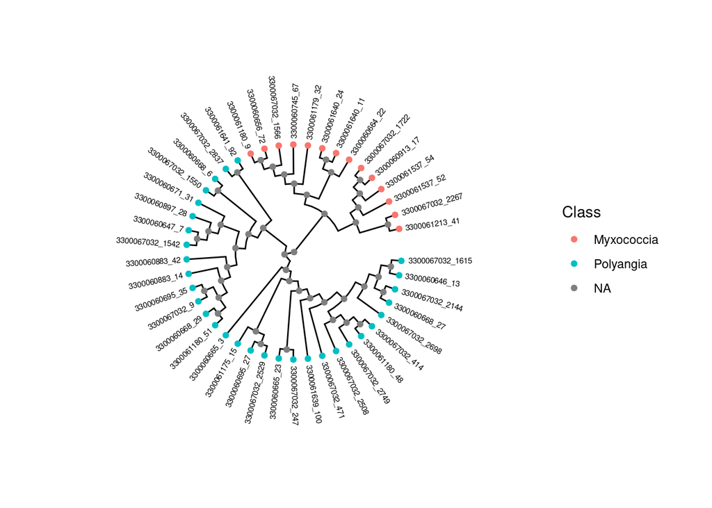

```r
ggtree(tree_Myxococcota, layout="circular")  %<+%
  NEON_MAGs_metagenomes_chemistry +
  geom_tiplab(size=2, hjust=-.1) +
  xlim(0,20) +
  geom_point(mapping=aes(color=Class))
```

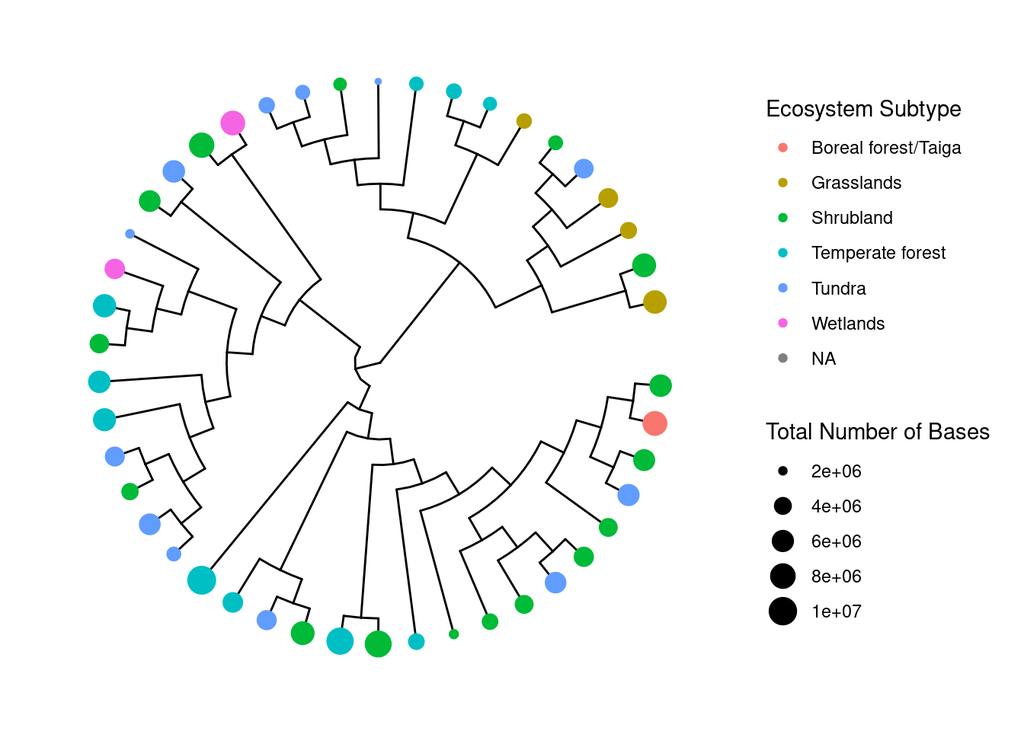

```r
ggtree(tree_Myxococcota, layout="circular")  %<+%
  NEON_MAGs_metagenomes_chemistry +
  geom_point2(mapping=aes(color=`Ecosystem Subtype`, size=`Total Number of Bases`))
```

```r
knitr::include_url("MyxoSankey.html")
```

[interactive chart not shown]

```r
kable(
  Myxococcota <- NEON_MAGs %>%
    filter(str_detect(`Phylum`, 'Myxococcota')))
```

| Bin ID | Site | Sample Name | Site ID | Subplot | Layer | Date | IMG Genome ID | Bin Quality | Bin Lineage | GTDB-Tk Taxonomy Lineage | Domain | Phylum | Class | Order | Family | Genus | Bin Completeness | Bin Contamination | Total Number of Bases | 5s rRNA | 16s rRNA | 23s rRNA | tRNA Genes | Gene Count | Scaffold Count | Assembly Type |
| --- | --- | --- | --- | --- | --- | --- | --- | --- | --- | --- | --- | --- | --- | --- | --- | --- | --- | --- | --- | --- | --- | --- | --- | --- | --- | --- |
| 3300060646_13 | Healy, Denali National Park, Alaska, USA | HEAL_048-M-20210622 | HEAL | 048 | M | 20210622 | 3300060646 | MQ | Bacteria; Myxococcota | Bacteria; Myxococcota; Polyangia; Polyangiales; Polyangiaceae | Bacteria | Myxococcota | Polyangia | Polyangiales | Polyangiaceae | NA | 82.87 | 9.73 | 7536959 | 1 | 1 | 1 | 55 | 7478 | 973 | Individual |
| 3300060647_7 | Yellowstone NP, Wyoming, USA | YELL_009-M-20210706 | YELL | 009 | M | 20210706 | 3300060647 | MQ | Bacteria | Bacteria; Myxococcota; Polyangia; Palsa-1104_A; Fen-1088 | Bacteria | Myxococcota | Polyangia | Palsa-1104_A | Fen-1088 | NA | 91.61 | 7.58 | 6624588 | 0 | 0 | 0 | 44 | 6225 | 474 | Individual |
| 3300060656_72 | Toolik Field Station, Alaska, USA | TOOL_005-O-20210806 | TOOL | 005 | O | 20210806 | 3300060656 | MQ | Bacteria; Myxococcota; Myxococcia; Myxococcales | Bacteria; Myxococcota; Myxococcia; Myxococcales; Myxococcaceae; JADGRA01 | Bacteria | Myxococcota | Myxococcia | Myxococcales | Myxococcaceae | JADGRA01 | 69.92 | 0.65 | 3028652 | 0 | 0 | 0 | 31 | 3182 | 480 | Individual |
| 3300060664_22 | Konza Prairie Bio Station, Kansas, USA | KONZ_042-M-20210720 | KONZ | 042 | M | 20210720 | 3300060664 | MQ | Bacteria; Myxococcota; Myxococcia | Bacteria; Myxococcota; Myxococcia; Myxococcales; Myxococcaceae; RPRB01 | Bacteria | Myxococcota | Myxococcia | Myxococcales | Myxococcaceae | RPRB01 | 60.79 | 1.61 | 3177148 | 0 | 0 | 0 | 29 | 3431 | 559 | Individual |
| 3300060665_23 | Lower Teakettle, Sierra National Forest, California, USA | TEAK_002-O-20210720 | TEAK | 002 | O | 20210720 | 3300060665 | HQ | Bacteria; Myxococcota | Bacteria; Myxococcota; Polyangia; Polyangiales; Polyangiaceae | Bacteria | Myxococcota | Polyangia | Polyangiales | Polyangiaceae | NA | 93.87 | 4.68 | 9156303 | 1 | 1 | 2 | 48 | 7903 | 109 | Individual |
| 3300060665_3 | Lower Teakettle, Sierra National Forest, California, USA | TEAK_002-O-20210720 | TEAK | 002 | O | 20210720 | 3300060665 | MQ | Bacteria | Bacteria; Myxococcota; Polyangia; Polyangiales; JAFGIB01 | Bacteria | Myxococcota | Polyangia | Polyangiales | JAFGIB01 | NA | 91.38 | 5.37 | 10348325 | 1 | 1 | 1 | 30 | 9267 | 998 | Individual |
| 3300060668_27 | Toolik Field Station, Alaska, USA | TOOL_043-O-20210803 | TOOL | 043 | O | 20210803 | 3300060668 | MQ | Bacteria; Myxococcota | Bacteria; Myxococcota; Polyangia; Polyangiales; Polyangiaceae; Palsa-1150 | Bacteria | Myxococcota | Polyangia | Polyangiales | Polyangiaceae | Palsa-1150 | 81.34 | 5.18 | 5969821 | 0 | 1 | 0 | 39 | 5680 | 439 | Individual |
| 3300060668_29 | Toolik Field Station, Alaska, USA | TOOL_043-O-20210803 | TOOL | 043 | O | 20210803 | 3300060668 | MQ | Bacteria | Bacteria; Myxococcota; Polyangia; Palsa-1104_A; Fen-1088; JADGRB01 | Bacteria | Myxococcota | Polyangia | Palsa-1104_A | Fen-1088 | JADGRB01 | 92.58 | 6.94 | 5758489 | 1 | 1 | 1 | 45 | 5457 | 259 | Individual |
| 3300060668_6 | Toolik Field Station, Alaska, USA | TOOL_043-O-20210803 | TOOL | 043 | O | 20210803 | 3300060668 | HQ | Bacteria | Bacteria; Myxococcota; Polyangia; Palsa-1104_A; Fen-1088 | Bacteria | Myxococcota | Polyangia | Palsa-1104_A | Fen-1088 | NA | 90.68 | 3.25 | 6164008 | 1 | 1 | 1 | 45 | 5395 | 393 | Individual |
| 3300060671_31 | Toolik Field Station, Alaska, USA | TOOL_003-O-20210805 | TOOL | 003 | O | 20210805 | 3300060671 | MQ | Bacteria | Bacteria; Myxococcota; Polyangia; Palsa-1104_A; Fen-1088; Fen-1118 | Bacteria | Myxococcota | Polyangia | Palsa-1104_A | Fen-1088 | Fen-1118 | 57.18 | 0.00 | 2024929 | 0 | 0 | 0 | 11 | 2099 | 408 | Individual |
| 3300060695_27 | Toolik Field Station, Alaska, USA | TOOL_006-O-20210804 | TOOL | 006 | O | 20210804 | 3300060695 | MQ | Bacteria; Myxococcota | Bacteria; Myxococcota; Polyangia; Polyangiales; Polyangiaceae; PMG-095 | Bacteria | Myxococcota | Polyangia | Polyangiales | Polyangiaceae | PMG-095 | 62.44 | 2.63 | 4942309 | 0 | 1 | 0 | 34 | 4940 | 722 | Individual |
| 3300060695_35 | Toolik Field Station, Alaska, USA | TOOL_006-O-20210804 | TOOL | 006 | O | 20210804 | 3300060695 | MQ | Bacteria | Bacteria; Myxococcota; Polyangia; Palsa-1104_A; Fen-1088; JADGRB01 | Bacteria | Myxococcota | Polyangia | Palsa-1104_A | Fen-1088 | JADGRB01 | 89.71 | 3.55 | 4854737 | 1 | 1 | 1 | 36 | 4417 | 100 | Individual |
| 3300060745_67 | Toolik Field Station, Alaska, USA | TOOL_002-O-20210804 | TOOL | 002 | O | 20210804 | 3300060745 | MQ | Bacteria; Myxococcota; Myxococcia; Myxococcales | Bacteria; Myxococcota; Myxococcia; Myxococcales; Myxococcaceae; JADGRA01 | Bacteria | Myxococcota | Myxococcia | Myxococcales | Myxococcaceae | JADGRA01 | 54.90 | 1.13 | 1913058 | 0 | 0 | 0 | 18 | 2005 | 328 | Individual |
| 3300060883_14 | Lower Teakettle, Sierra National Forest, California, USA | TEAK_005-O-20210728 | TEAK | 005 | O | 20210728 | 3300060883 | MQ | Bacteria | Bacteria; Myxococcota; Polyangia; Palsa-1104_A; Fen-1088 | Bacteria | Myxococcota | Polyangia | Palsa-1104_A | Fen-1088 | NA | 89.76 | 8.17 | 6490021 | 0 | 1 | 0 | 38 | 6001 | 431 | Individual |
| 3300060883_42 | Lower Teakettle, Sierra National Forest, California, USA | TEAK_005-O-20210728 | TEAK | 005 | O | 20210728 | 3300060883 | MQ | Bacteria | Bacteria; Myxococcota; Polyangia; Palsa-1104_A; Fen-1088 | Bacteria | Myxococcota | Polyangia | Palsa-1104_A | Fen-1088 | NA | 86.21 | 5.48 | 6185064 | 1 | 1 | 1 | 33 | 5778 | 693 | Individual |
| 3300060897_28 | Chase Lake Wetlands, North Dakota, USA | WOOD_001-M-20210714 | WOOD | 001 | M | 20210714 | 3300060897 | MQ | Bacteria | Bacteria; Myxococcota; Polyangia; Palsa-1104_A; Fen-1088 | Bacteria | Myxococcota | Polyangia | Palsa-1104_A | Fen-1088 | NA | 51.04 | 3.51 | 5120833 | 0 | 0 | 0 | 18 | 5177 | 918 | Individual |
| 3300060913_17 | Toolik Field Station, Alaska, USA | TOOL_004-O-20210805 | TOOL | 004 | O | 20210805 | 3300060913 | MQ | Bacteria | Bacteria; Myxococcota; Myxococcia; Myxococcales; 40CM-4-68-19; 40CM-4-68-19 | Bacteria | Myxococcota | Myxococcia | Myxococcales | 40CM-4-68-19 | 40CM-4-68-19 | 89.41 | 4.19 | 4725575 | 0 | 0 | 0 | 40 | 4979 | 454 | Individual |
| 3300061175_15 | Yellowstone NP, Wyoming, USA | YELL_012-O-20210708 | YELL | 012 | O | 20210708 | 3300061175 | MQ | Bacteria; Myxococcota | Bacteria; Myxococcota; Polyangia; Polyangiales; Polyangiaceae; PMG-095 | Bacteria | Myxococcota | Polyangia | Polyangiales | Polyangiaceae | PMG-095 | 68.36 | 3.55 | 5197081 | 0 | 0 | 0 | 27 | 5175 | 859 | Individual |
| 3300061179_32 | Wind River Experimental Forest, Washington, USA | WREF_001-O-20210621 | WREF | 001 | O | 20210621 | 3300061179 | MQ | Bacteria; Myxococcota; Myxococcia; Myxococcales | Bacteria; Myxococcota; Myxococcia; Myxococcales; Myxococcaceae; JADGRA01 | Bacteria | Myxococcota | Myxococcia | Myxococcales | Myxococcaceae | JADGRA01 | 63.16 | 0.88 | 2895024 | 0 | 0 | 0 | 23 | 2892 | 323 | Individual |
| 3300061180_48 | Toolik Field Station, Alaska, USA | TOOL_044-O-20210803 | TOOL | 044 | O | 20210803 | 3300061180 | MQ | Bacteria; Myxococcota | Bacteria; Myxococcota; Polyangia; Polyangiales; Polyangiaceae; Palsa-1150 | Bacteria | Myxococcota | Polyangia | Polyangiales | Polyangiaceae | Palsa-1150 | 87.88 | 3.35 | 5684876 | 1 | 1 | 1 | 44 | 5416 | 435 | Individual |
| 3300061180_51 | Toolik Field Station, Alaska, USA | TOOL_044-O-20210803 | TOOL | 044 | O | 20210803 | 3300061180 | MQ | Bacteria | Bacteria; Myxococcota; Polyangia; Palsa-1104_A; Fen-1088; JADGRB01 | Bacteria | Myxococcota | Polyangia | Palsa-1104_A | Fen-1088 | JADGRB01 | 60.41 | 0.65 | 2968483 | 1 | 0 | 1 | 17 | 3001 | 499 | Individual |
| 3300061180_9 | Toolik Field Station, Alaska, USA | TOOL_044-O-20210803 | TOOL | 044 | O | 20210803 | 3300061180 | MQ | Bacteria; Myxococcota; Myxococcia; Myxococcales | Bacteria; Myxococcota; Myxococcia; Myxococcales; Myxococcaceae; JADGRA01 | Bacteria | Myxococcota | Myxococcia | Myxococcales | Myxococcaceae | JADGRA01 | 81.06 | 0.97 | 3462978 | 1 | 1 | 1 | 34 | 3467 | 376 | Individual |
| 3300061213_41 | National Grasslands LBJ, Texas, USA | CLBJ_033-M-20210505 | CLBJ | 033 | M | 20210505 | 3300061213 | HQ | Bacteria; Myxococcota; Myxococcia; Myxococcales; Anaeromyxobacteraceae; Anaeromyxobacter | Bacteria; Myxococcota; Myxococcia; Myxococcales; Anaeromyxobacteraceae; R267 | Bacteria | Myxococcota | Myxococcia | Myxococcales | Anaeromyxobacteraceae | R267 | 99.35 | 1.94 | 6725840 | 1 | 1 | 1 | 47 | 6275 | 114 | Individual |
| 3300061537_52 | National Grasslands LBJ, Texas, USA | CLBJ_003-M-20210506 | CLBJ | 003 | M | 20210506 | 3300061537 | MQ | Bacteria; Myxococcota | Bacteria; Myxococcota; Myxococcia; Myxococcales; 40CM-4-68-19; 40CM-4-68-19 | Bacteria | Myxococcota | Myxococcia | Myxococcales | 40CM-4-68-19 | 40CM-4-68-19 | 76.13 | 6.24 | 3680175 | 0 | 0 | 0 | 25 | 3757 | 497 | Individual |
| 3300061537_54 | National Grasslands LBJ, Texas, USA | CLBJ_003-M-20210506 | CLBJ | 003 | M | 20210506 | 3300061537 | MQ | Bacteria | Bacteria; Myxococcota; Myxococcia; Myxococcales; 40CM-4-68-19; 40CM-4-68-19 | Bacteria | Myxococcota | Myxococcia | Myxococcales | 40CM-4-68-19 | 40CM-4-68-19 | 85.28 | 3.61 | 4824793 | 0 | 1 | 0 | 47 | 4928 | 547 | Individual |
| 3300061639_100 | Niwot Ridge, Colorado, USA | NIWO_004-O-20210726 | NIWO | 004 | O | 20210726 | 3300061639 | MQ | Bacteria; Myxococcota; unclassified; Polyangiales | Bacteria; Myxococcota; Polyangia; Polyangiales; Polyangiaceae | Bacteria | Myxococcota | Polyangia | Polyangiales | Polyangiaceae | NA | 53.59 | 1.29 | 3550777 | 0 | 0 | 0 | 19 | 3641 | 706 | Individual |
| 3300061640_11 | Niwot Ridge, Colorado, USA | NIWO_003-M-20210727 | NIWO | 003 | M | 20210727 | 3300061640 | MQ | Bacteria; Myxococcota; Myxococcia; Myxococcales | Bacteria; Myxococcota; Myxococcia; Myxococcales; Myxococcaceae | Bacteria | Myxococcota | Myxococcia | Myxococcales | Myxococcaceae | NA | 51.93 | 1.75 | 2762666 | 0 | 0 | 0 | 14 | 2845 | 376 | Individual |
| 3300061640_24 | Niwot Ridge, Colorado, USA | NIWO_003-M-20210727 | NIWO | 003 | M | 20210727 | 3300061640 | MQ | Bacteria; Myxococcota; Myxococcia; Myxococcales | Bacteria; Myxococcota; Myxococcia; Myxococcales; Myxococcaceae | Bacteria | Myxococcota | Myxococcia | Myxococcales | Myxococcaceae | NA | 71.05 | 2.26 | 3263245 | 1 | 1 | 1 | 22 | 3359 | 392 | Individual |
| 3300061641_81 | Chase Lake Wetlands, North Dakota, USA | WOOD_024-O-20210714 | WOOD | 024 | O | 20210714 | 3300061641 | MQ | Bacteria | Bacteria; Myxococcota_A; UBA9160; UBA9160; UBA4427 | Bacteria | Myxococcota_A | UBA9160 | UBA9160 | UBA4427 | NA | 73.92 | 3.91 | 4206297 | 1 | 1 | 1 | 31 | 4209 | 626 | Individual |
| 3300061641_89 | Chase Lake Wetlands, North Dakota, USA | WOOD_024-O-20210714 | WOOD | 024 | O | 20210714 | 3300061641 | MQ | Bacteria | Bacteria; Myxococcota_A; UBA9160; SZUA-336; SZUA-336; VGRW01 | Bacteria | Myxococcota_A | UBA9160 | SZUA-336 | SZUA-336 | VGRW01 | 79.47 | 3.45 | 4425127 | 1 | 1 | 0 | 39 | 4554 | 346 | Individual |
| 3300061641_92 | Chase Lake Wetlands, North Dakota, USA | WOOD_024-O-20210714 | WOOD | 024 | O | 20210714 | 3300061641 | HQ | Bacteria | Bacteria; Myxococcota; Polyangia; Haliangiales; Haliangiaceae; JABFXX01 | Bacteria | Myxococcota | Polyangia | Haliangiales | Haliangiaceae | JABFXX01 | 90.56 | 4.19 | 7457808 | 1 | 1 | 1 | 62 | 7072 | 861 | Individual |
| 3300067032_1542 | NEON combined assembly | NA | NA | NA | NA | NA | 3300067032 | MQ | Bacteria | Bacteria; Myxococcota; Polyangia; Palsa-1104_A; Fen-1088 | Bacteria | Myxococcota | Polyangia | Palsa-1104_A | Fen-1088 | NA | 61.74 | 0.00 | 4662289 | 1 | 0 | 1 | 25 | 4441 | 402 | Combined |
| 3300067032_1550 | NEON combined assembly | NA | NA | NA | NA | NA | 3300067032 | MQ | Bacteria | Bacteria; Myxococcota; Polyangia; Palsa-1104_A; Fen-1088 | Bacteria | Myxococcota | Polyangia | Palsa-1104_A | Fen-1088 | NA | 87.69 | 2.58 | 5743332 | 1 | 1 | 1 | 39 | 4971 | 386 | Combined |
| 3300067032_1566 | NEON combined assembly | NA | NA | NA | NA | NA | 3300067032 | MQ | Bacteria; Myxococcota; Myxococcia; Myxococcales | Bacteria; Myxococcota; Myxococcia; Myxococcales; Myxococcaceae; JADGRA01 | Bacteria | Myxococcota | Myxococcia | Myxococcales | Myxococcaceae | JADGRA01 | 70.34 | 0.00 | 2648925 | 0 | 0 | 0 | 14 | 2575 | 220 | Combined |
| 3300067032_1615 | NEON combined assembly | NA | NA | NA | NA | NA | 3300067032 | MQ | Bacteria; Myxococcota; unclassified; Polyangiales | Bacteria; Myxococcota; Polyangia; Polyangiales; Polyangiaceae | Bacteria | Myxococcota | Polyangia | Polyangiales | Polyangiaceae | NA | 80.99 | 5.00 | 6190111 | 1 | 1 | 1 | 37 | 5671 | 441 | Combined |
| 3300067032_1722 | NEON combined assembly | NA | NA | NA | NA | NA | 3300067032 | MQ | Bacteria; Myxococcota | Bacteria; Myxococcota; Myxococcia; Myxococcales; 40CM-4-68-19; 40CM-4-68-19 | Bacteria | Myxococcota | Myxococcia | Myxococcales | 40CM-4-68-19 | 40CM-4-68-19 | 52.79 | 0.00 | 3004577 | 0 | 0 | 0 | 7 | 3141 | 343 | Combined |
| 3300067032_2144 | NEON combined assembly | NA | NA | NA | NA | NA | 3300067032 | MQ | Bacteria; Myxococcota; unclassified; Polyangiales | Bacteria; Myxococcota; Polyangia; Polyangiales; Polyangiaceae; Palsa-1150 | Bacteria | Myxococcota | Polyangia | Polyangiales | Polyangiaceae | Palsa-1150 | 85.97 | 2.58 | 5853191 | 1 | 1 | 0 | 46 | 5306 | 214 | Combined |
| 3300067032_2267 | NEON combined assembly | NA | NA | NA | NA | NA | 3300067032 | HQ | Bacteria; Myxococcota; Myxococcia; Myxococcales | Bacteria; Myxococcota; Myxococcia; Myxococcales; Anaeromyxobacteraceae; R267 | Bacteria | Myxococcota | Myxococcia | Myxococcales | Anaeromyxobacteraceae | R267 | 97.46 | 2.58 | 6967385 | 1 | 1 | 1 | 45 | 6518 | 204 | Combined |
| 3300067032_247 | NEON combined assembly | NA | NA | NA | NA | NA | 3300067032 | MQ | Bacteria; Myxococcota | Bacteria; Myxococcota; Polyangia; Polyangiales; Polyangiaceae | Bacteria | Myxococcota | Polyangia | Polyangiales | Polyangiaceae | NA | 92.51 | 4.52 | 8908816 | 1 | 0 | 1 | 44 | 7862 | 239 | Combined |
| 3300067032_2508 | NEON combined assembly | NA | NA | NA | NA | NA | 3300067032 | MQ | Bacteria; Myxococcota; unclassified; Polyangiales | Bacteria; Myxococcota; Polyangia; Polyangiales; Polyangiaceae; Palsa-1150 | Bacteria | Myxococcota | Polyangia | Polyangiales | Polyangiaceae | Palsa-1150 | 61.04 | 2.63 | 3523765 | 0 | 0 | 0 | 14 | 3161 | 338 | Combined |
| 3300067032_2529 | NEON combined assembly | NA | NA | NA | NA | NA | 3300067032 | MQ | Bacteria; Myxococcota | Bacteria; Myxococcota; Polyangia; Polyangiales; Polyangiaceae; PMG-095 | Bacteria | Myxococcota | Polyangia | Polyangiales | Polyangiaceae | PMG-095 | 72.98 | 0.00 | 6904733 | 0 | 0 | 0 | 28 | 6315 | 442 | Combined |
| 3300067032_2698 | NEON combined assembly | NA | NA | NA | NA | NA | 3300067032 | MQ | Bacteria; Myxococcota; unclassified; Polyangiales | Bacteria; Myxococcota; Polyangia; Polyangiales; Polyangiaceae; Palsa-1150 | Bacteria | Myxococcota | Polyangia | Polyangiales | Polyangiaceae | Palsa-1150 | 75.75 | 1.94 | 4399844 | 0 | 0 | 0 | 31 | 4081 | 312 | Combined |
| 3300067032_2749 | NEON combined assembly | NA | NA | NA | NA | NA | 3300067032 | MQ | Bacteria; Myxococcota; unclassified; Polyangiales | Bacteria; Myxococcota; Polyangia; Polyangiales; Polyangiaceae; Palsa-1150 | Bacteria | Myxococcota | Polyangia | Polyangiales | Polyangiaceae | Palsa-1150 | 79.68 | 1.29 | 4398150 | 1 | 1 | 1 | 32 | 4001 | 269 | Combined |
| 3300067032_2837 | NEON combined assembly | NA | NA | NA | NA | NA | 3300067032 | MQ | Bacteria | Bacteria; Myxococcota; Polyangia; Haliangiales; Haliangiaceae; JABFXX01 | Bacteria | Myxococcota | Polyangia | Haliangiales | Haliangiaceae | JABFXX01 | 77.76 | 3.23 | 7838323 | 0 | 1 | 0 | 52 | 7669 | 786 | Combined |
| 3300067032_312 | NEON combined assembly | NA | NA | NA | NA | NA | 3300067032 | MQ | Bacteria | Bacteria; Myxococcota_A; UBA9160; SZUA-336; SZUA-336; VGRW01 | Bacteria | Myxococcota_A | UBA9160 | SZUA-336 | SZUA-336 | VGRW01 | 84.10 | 3.36 | 4222441 | 1 | 0 | 1 | 38 | 4279 | 289 | Combined |
| 3300067032_414 | NEON combined assembly | NA | NA | NA | NA | NA | 3300067032 | MQ | Bacteria; Myxococcota; unclassified; Polyangiales | Bacteria; Myxococcota; Polyangia; Polyangiales; Polyangiaceae; Palsa-1150 | Bacteria | Myxococcota | Polyangia | Polyangiales | Polyangiaceae | Palsa-1150 | 87.44 | 2.71 | 5009044 | 1 | 1 | 1 | 37 | 4474 | 243 | Combined |
| 3300067032_471 | NEON combined assembly | NA | NA | NA | NA | NA | 3300067032 | MQ | Bacteria; Myxococcota; unclassified; Polyangiales | Bacteria; Myxococcota; Polyangia; Polyangiales; Polyangiaceae; Palsa-1150 | Bacteria | Myxococcota | Polyangia | Polyangiales | Polyangiaceae | Palsa-1150 | 54.39 | 0.00 | 2078064 | 1 | 1 | 1 | 18 | 2051 | 222 | Combined |
| 3300067032_844 | NEON combined assembly | NA | NA | NA | NA | NA | 3300067032 | MQ | Bacteria | Bacteria; Myxococcota_A; UBA9160; UBA9160; UBA6930; VGRF01 | Bacteria | Myxococcota_A | UBA9160 | UBA9160 | UBA6930 | VGRF01 | 60.33 | 1.61 | 3444426 | 1 | 1 | 1 | 22 | 3658 | 512 | Combined |
| 3300067032_9 | NEON combined assembly | NA | NA | NA | NA | NA | 3300067032 | MQ | Bacteria | Bacteria; Myxococcota; Polyangia; Palsa-1104_A; Fen-1088; JADGRB01 | Bacteria | Myxococcota | Polyangia | Palsa-1104_A | Fen-1088 | JADGRB01 | 73.68 | 0.00 | 3797552 | 0 | 1 | 0 | 15 | 3767 | 439 | Combined |

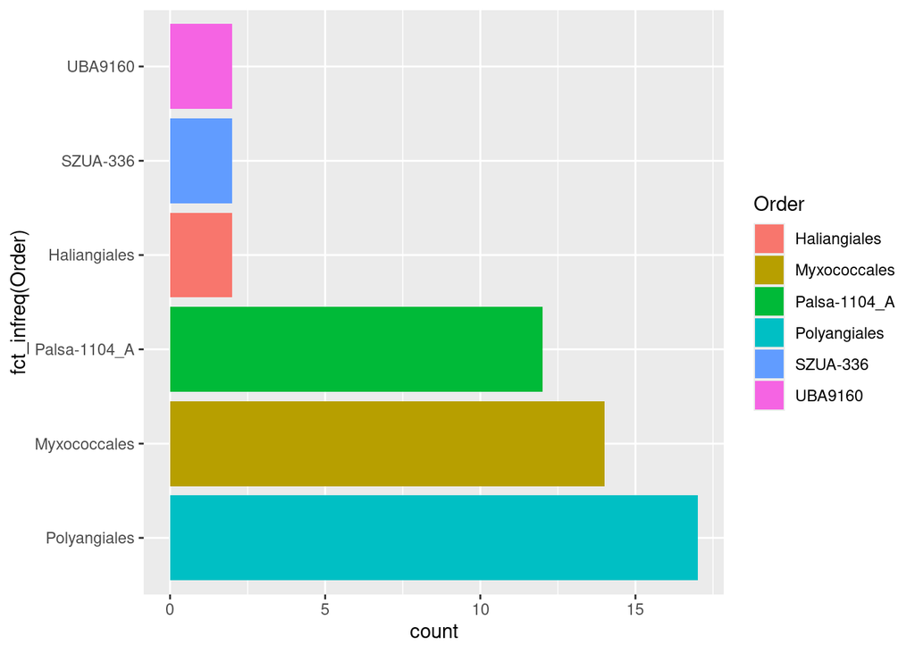

```r
Myxococcota %>%
  ggplot(aes(x = fct_infreq(Order))) +
  geom_bar(aes(fill=Order)) +
  coord_flip()
```

```r
datatable(NEON_MAGs_Ind_tax_sample %>%
  filter(str_detect(`Phylum`, "Myxococcota")) %>%
  count(Site, sort = TRUE))
```

|  | Site | n |
| --- | --- | --- |
| 1 | Toolik Field Station, Alaska, USA | 12 |
| 2 | Chase Lake Wetlands, North Dakota, USA | 4 |
| 3 | Lower Teakettle, Sierra National Forest, California, USA | 4 |
| 4 | National Grasslands LBJ, Texas, USA | 3 |
| 5 | Niwot Ridge, Colorado, USA | 3 |
| 6 | Yellowstone NP, Wyoming, USA | 2 |
| 7 | Healy, Denali National Park, Alaska, USA | 1 |
| 8 | Konza Prairie Bio Station, Kansas, USA | 1 |
| 9 | Wind River Experimental Forest, Washington, USA | 1 |

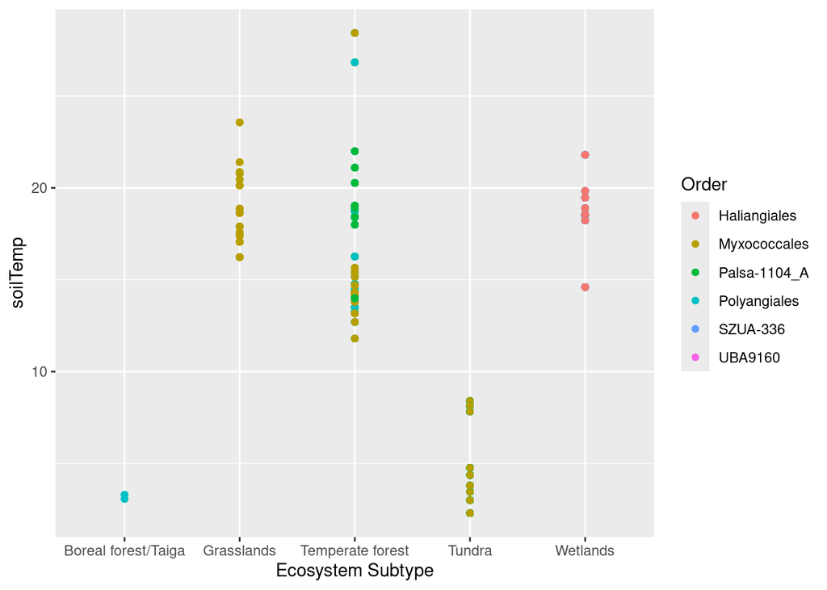

```r
combined_df %>%
  left_join(NEON_MAGs, by = c("siteID" = "Site ID")) %>%
  filter(str_detect(`Phylum`, "Myxococcota")) %>%
  ggplot(aes(x = `Ecosystem Subtype`, y = `soilTemp`)) +
  geom_point(aes(color=Order))
```

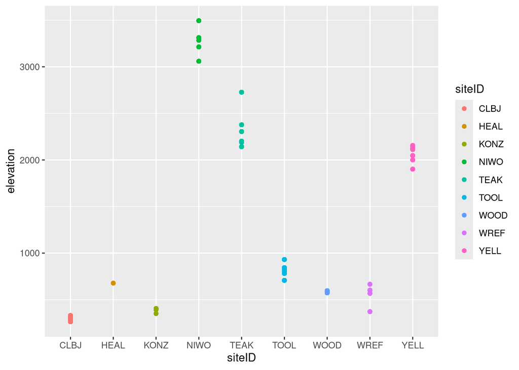

```r
combined_df %>%
  left_join(NEON_MAGs, by = c("siteID" = "Site ID")) %>%
  filter(str_detect(`Phylum`, "Myxococcota")) %>%
   ggplot(aes(x = `siteID`, y = `elevation`)) +
  geom_point(aes(color=siteID))
```

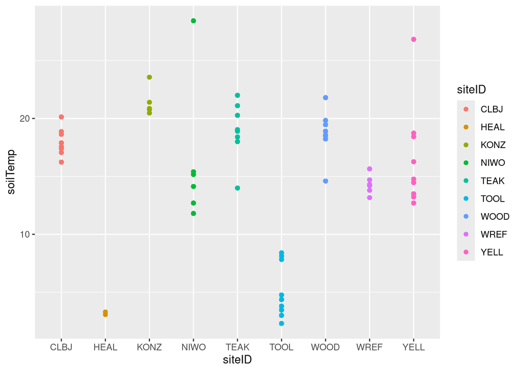

```r
combined_df %>%
  left_join(NEON_MAGs, by = c("siteID" = "Site ID")) %>%
  filter(str_detect(`Phylum`, "Myxococcota")) %>%
   ggplot(aes(x = `siteID`, y = `soilTemp`)) +
  geom_point(aes(color=siteID))
```

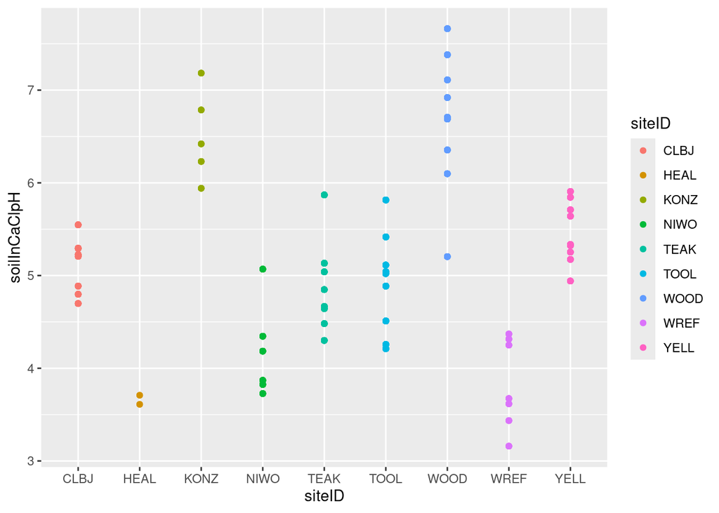

```r
combined_df %>%
  left_join(NEON_MAGs, by = c("siteID" = "Site ID")) %>%
  filter(str_detect(`Phylum`, "Myxococcota")) %>%
   ggplot(aes(x = `siteID`, y = `soilInCaClpH`)) +
  geom_point(aes(color=siteID))
```

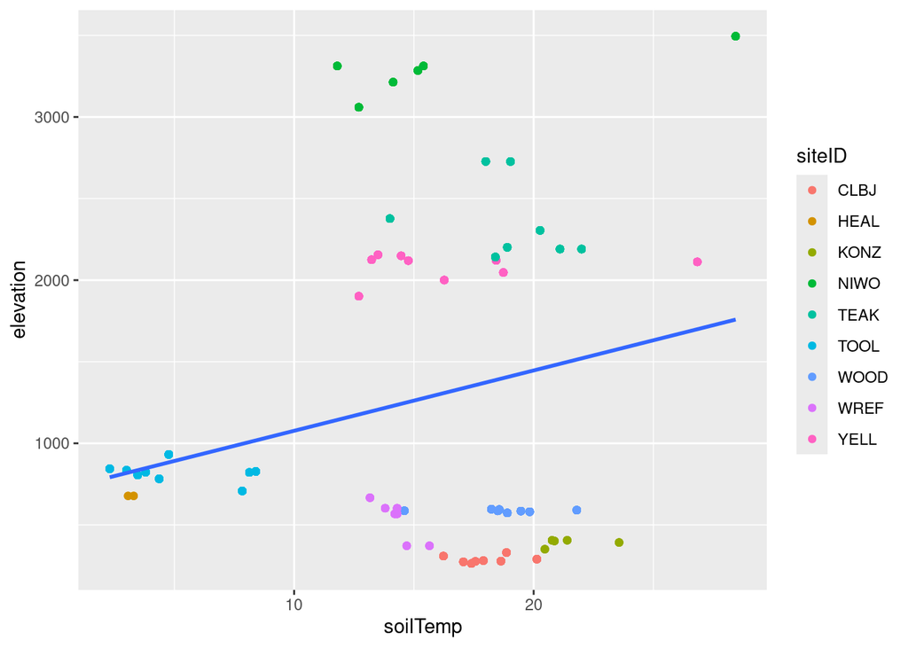

```r
combined_df %>%
  left_join(NEON_MAGs, by = c("siteID" = "Site ID")) %>%
  filter(str_detect(`Phylum`, "Myxococcota")) %>%
   ggplot(aes(x = `soilTemp`, y = `elevation`)) +
  geom_point(aes(color=siteID)) +
  geom_smooth(method = "lm", se = FALSE)
```

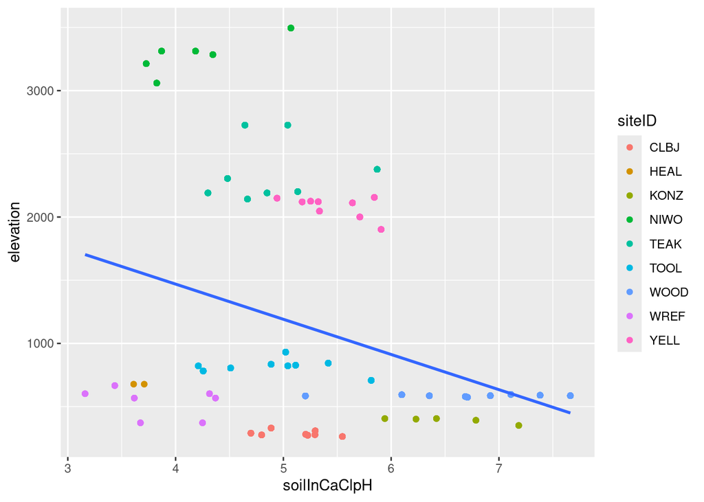

```r
combined_df %>%
  left_join(NEON_MAGs, by = c("siteID" = "Site ID")) %>%
  filter(str_detect(`Phylum`, "Myxococcota")) %>%
   ggplot(aes(x = `soilInCaClpH`, y = `elevation`)) +
  geom_point(aes(color=siteID)) +
  geom_smooth(method = "lm", se = FALSE)
```

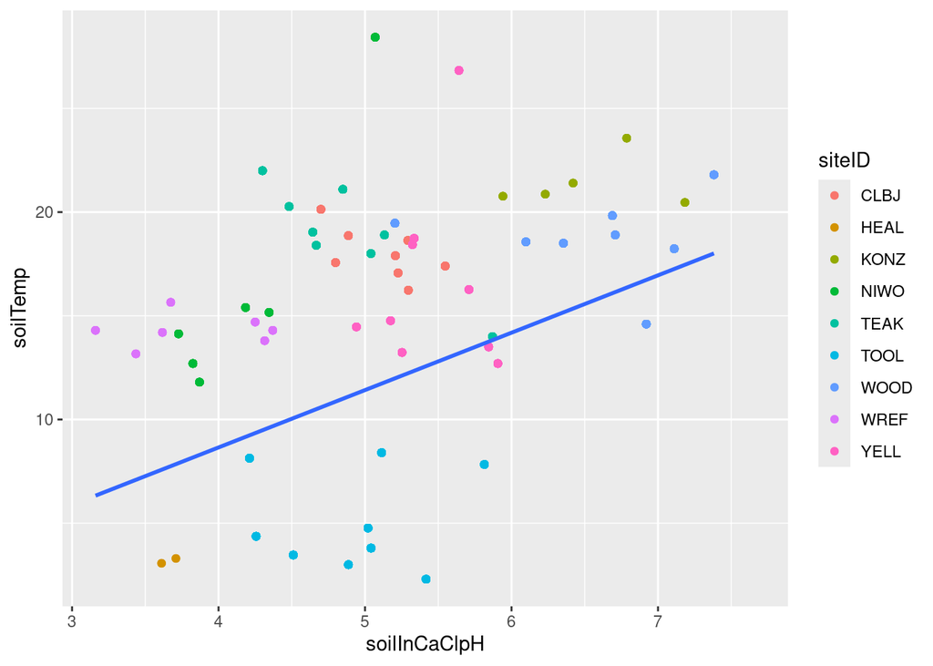

```r
combined_df %>%
  left_join(NEON_MAGs, by = c("siteID" = "Site ID")) %>%
  filter(str_detect(`Phylum`, "Myxococcota")) %>%
   ggplot(aes(x = `soilInCaClpH`, y = `soilTemp`)) +
  geom_point(aes(color=siteID)) +
  geom_smooth(method = "lm", se = FALSE)
```

### BONA

```r
kable(
  Site_MAGS <- NEON_MAGs %>%
  filter(str_detect(`Site`, 'Caribou Creek')))
```

| Bin ID | Site | Sample Name | Site ID | Subplot | Layer | Date | IMG Genome ID | Bin Quality | Bin Lineage | GTDB-Tk Taxonomy Lineage | Domain | Phylum | Class | Order | Family | Genus | Bin Completeness | Bin Contamination | Total Number of Bases | 5s rRNA | 16s rRNA | 23s rRNA | tRNA Genes | Gene Count | Scaffold Count | Assembly Type |
| --- | --- | --- | --- | --- | --- | --- | --- | --- | --- | --- | --- | --- | --- | --- | --- | --- | --- | --- | --- | --- | --- | --- | --- | --- | --- | --- |
| 3300060644_13 | Caribou Creek Watershed, Alaska, USA | BONA_009-O-20210707 | BONA | 009 | O | 20210707 | 3300060644 | MQ | Bacteria; Actinomycetota; Thermoleophilia; Solirubrobacterales | Bacteria; Actinobacteriota; Thermoleophilia; Solirubrobacterales; Solirubrobacteraceae; Palsa-744 | Bacteria | Actinobacteriota | Thermoleophilia | Solirubrobacterales | Solirubrobacteraceae | Palsa-744 | 96.72 | 1.71 | 2963684 | 1 | 0 | 1 | 47 | 2890 | 10 | Individual |
| 3300060644_14 | Caribou Creek Watershed, Alaska, USA | BONA_009-O-20210707 | BONA | 009 | O | 20210707 | 3300060644 | MQ | Bacteria; Acidobacteriota; Terriglobia; Terriglobales; Acidobacteriaceae; Granulicella; Granulicella mallensis | Bacteria; Acidobacteriota; Acidobacteriae; Acidobacteriales; Acidobacteriaceae; UBA5172 | Bacteria | Acidobacteriota | Acidobacteriae | Acidobacteriales | Acidobacteriaceae | UBA5172 | 72.68 | 5.17 | 2831874 | 0 | 0 | 0 | 34 | 2691 | 186 | Individual |
| 3300060644_15 | Caribou Creek Watershed, Alaska, USA | BONA_009-O-20210707 | BONA | 009 | O | 20210707 | 3300060644 | MQ | Bacteria; Actinomycetota; Actinomycetes; Mycobacteriales; Mycobacteriaceae; Mycobacterium | Bacteria; Actinobacteriota; Actinomycetia; Mycobacteriales; Mycobacteriaceae; Mycobacterium | Bacteria | Actinobacteriota | Actinomycetia | Mycobacteriales | Mycobacteriaceae | Mycobacterium | 56.18 | 5.83 | 3272984 | 0 | 1 | 0 | 20 | 3606 | 529 | Individual |
| 3300060644_2 | Caribou Creek Watershed, Alaska, USA | BONA_009-O-20210707 | BONA | 009 | O | 20210707 | 3300060644 | MQ | Bacteria; Pseudomonadota; Alphaproteobacteria; Rhodospirillales | Bacteria; Proteobacteria; Alphaproteobacteria; Acetobacterales; Acetobacteraceae; Acidisoma; Acidisoma sp009765865 | Bacteria | Proteobacteria | Alphaproteobacteria | Acetobacterales | Acetobacteraceae | Acidisoma | 74.60 | 0.50 | 3609891 | 0 | 0 | 0 | 25 | 3729 | 401 | Individual |
| 3300060644_25 | Caribou Creek Watershed, Alaska, USA | BONA_009-O-20210707 | BONA | 009 | O | 20210707 | 3300060644 | MQ | Bacteria; Pseudomonadota; Gammaproteobacteria | Bacteria; Proteobacteria; Gammaproteobacteria; Steroidobacterales; Steroidobacteraceae; Bog-1198 | Bacteria | Proteobacteria | Gammaproteobacteria | Steroidobacterales | Steroidobacteraceae | Bog-1198 | 57.93 | 3.45 | 2233801 | 0 | 0 | 0 | 14 | 2167 | 219 | Individual |
| 3300060644_26 | Caribou Creek Watershed, Alaska, USA | BONA_009-O-20210707 | BONA | 009 | O | 20210707 | 3300060644 | MQ | Bacteria; Actinomycetota; Actinomycetes; Mycobacteriales; Mycobacteriaceae; Mycobacterium | Bacteria; Actinobacteriota; Actinomycetia; Mycobacteriales; Mycobacteriaceae; Mycobacterium | Bacteria | Actinobacteriota | Actinomycetia | Mycobacteriales | Mycobacteriaceae | Mycobacterium | 88.06 | 2.26 | 5789977 | 1 | 0 | 0 | 42 | 6319 | 671 | Individual |
| 3300060644_35 | Caribou Creek Watershed, Alaska, USA | BONA_009-O-20210707 | BONA | 009 | O | 20210707 | 3300060644 | MQ | Bacteria; Pseudomonadota; Alphaproteobacteria; Rhodospirillales; Acetobacteraceae | Bacteria; Proteobacteria; Alphaproteobacteria; Acetobacterales; Acetobacteraceae; Acidocella | Bacteria | Proteobacteria | Alphaproteobacteria | Acetobacterales | Acetobacteraceae | Acidocella | 97.51 | 0.58 | 3366152 | 0 | 0 | 0 | 46 | 3443 | 121 | Individual |
| 3300060644_42 | Caribou Creek Watershed, Alaska, USA | BONA_009-O-20210707 | BONA | 009 | O | 20210707 | 3300060644 | MQ | Bacteria | Bacteria; Eremiobacterota; Eremiobacteria; Baltobacterales; Baltobacteraceae; Tumulicola | Bacteria | Eremiobacterota | Eremiobacteria | Baltobacterales | Baltobacteraceae | Tumulicola | 91.48 | 1.39 | 2900940 | 1 | 1 | 0 | 40 | 3030 | 156 | Individual |
| 3300060644_47 | Caribou Creek Watershed, Alaska, USA | BONA_009-O-20210707 | BONA | 009 | O | 20210707 | 3300060644 | MQ | Bacteria | Bacteria; Eremiobacterota; Eremiobacteria; Baltobacterales; Baltobacteraceae; Lustribacter | Bacteria | Eremiobacterota | Eremiobacteria | Baltobacterales | Baltobacteraceae | Lustribacter | 83.64 | 0.46 | 4737011 | 1 | 0 | 1 | 34 | 5119 | 458 | Individual |
| 3300060644_5 | Caribou Creek Watershed, Alaska, USA | BONA_009-O-20210707 | BONA | 009 | O | 20210707 | 3300060644 | MQ | Bacteria; Acidobacteriota; Terriglobia; Terriglobales; Acidobacteriaceae; unclassified; Acidobacteriaceae bacterium KBS 83 | Bacteria; Acidobacteriota; Acidobacteriae; Acidobacteriales; Acidobacteriaceae; KBS-83 | Bacteria | Acidobacteriota | Acidobacteriae | Acidobacteriales | Acidobacteriaceae | KBS-83 | 56.38 | 6.90 | 3141095 | 0 | 0 | 0 | 20 | 3089 | 368 | Individual |
| 3300060644_52 | Caribou Creek Watershed, Alaska, USA | BONA_009-O-20210707 | BONA | 009 | O | 20210707 | 3300060644 | MQ | Bacteria; Pseudomonadota | Bacteria; Proteobacteria; Gammaproteobacteria; Steroidobacterales; Steroidobacteraceae; Bog-1198 | Bacteria | Proteobacteria | Gammaproteobacteria | Steroidobacterales | Steroidobacteraceae | Bog-1198 | 58.62 | 5.17 | 4153034 | 0 | 0 | 0 | 23 | 4390 | 620 | Individual |
| 3300060644_6 | Caribou Creek Watershed, Alaska, USA | BONA_009-O-20210707 | BONA | 009 | O | 20210707 | 3300060644 | MQ | Bacteria; Pseudomonadota; Betaproteobacteria; Burkholderiales; Burkholderiaceae; Caballeronia | Bacteria; Proteobacteria; Gammaproteobacteria; Burkholderiales; Burkholderiaceae; Caballeronia | Bacteria | Proteobacteria | Gammaproteobacteria | Burkholderiales | Burkholderiaceae | Caballeronia | 79.66 | 0.86 | 6374505 | 0 | 0 | 0 | 43 | 6260 | 340 | Individual |
| 3300060644_7 | Caribou Creek Watershed, Alaska, USA | BONA_009-O-20210707 | BONA | 009 | O | 20210707 | 3300060644 | MQ | Bacteria | Bacteria; Verrucomicrobiota; Verrucomicrobiae; Chthoniobacterales; JAFAMB01; JAFAMB01 | Bacteria | Verrucomicrobiota | Verrucomicrobiae | Chthoniobacterales | JAFAMB01 | JAFAMB01 | 72.87 | 3.18 | 4371866 | 0 | 0 | 0 | 28 | 4408 | 377 | Individual |
| 3300060645_18 | Caribou Creek Watershed, Alaska, USA | BONA_006-O-20210707 | BONA | 006 | O | 20210707 | 3300060645 | MQ | Bacteria; Pseudomonadota; Alphaproteobacteria | Bacteria; Proteobacteria; Alphaproteobacteria; BOG-932; BOG-932; BOG-932 | Bacteria | Proteobacteria | Alphaproteobacteria | BOG-932 | BOG-932 | BOG-932 | 96.94 | 4.37 | 6281685 | 0 | 1 | 1 | 56 | 6529 | 337 | Individual |
| 3300060645_2 | Caribou Creek Watershed, Alaska, USA | BONA_006-O-20210707 | BONA | 006 | O | 20210707 | 3300060645 | MQ | Bacteria; Actinomycetota; Actinomycetes; Micrococcales; Microbacteriaceae | Bacteria; Actinobacteriota; Actinomycetia; Actinomycetales; Microbacteriaceae; Plantibacter | Bacteria | Actinobacteriota | Actinomycetia | Actinomycetales | Microbacteriaceae | Plantibacter | 52.69 | 5.53 | 2146885 | 0 | 0 | 0 | 23 | 2318 | 422 | Individual |
| 3300060645_23 | Caribou Creek Watershed, Alaska, USA | BONA_006-O-20210707 | BONA | 006 | O | 20210707 | 3300060645 | MQ | Bacteria; Actinomycetota; Actinomycetes; Micrococcales; Microbacteriaceae | Bacteria; Actinobacteriota; Actinomycetia; Actinomycetales; Microbacteriaceae; Leifsonia_B | Bacteria | Actinobacteriota | Actinomycetia | Actinomycetales | Microbacteriaceae | Leifsonia_B | 99.49 | 1.52 | 4042696 | 3 | 1 | 0 | 49 | 3775 | 12 | Individual |
| 3300060645_3 | Caribou Creek Watershed, Alaska, USA | BONA_006-O-20210707 | BONA | 006 | O | 20210707 | 3300060645 | MQ | Bacteria; Pseudomonadota; Alphaproteobacteria; Rhodospirillales; Acetobacteraceae; Acidocella | Bacteria; Proteobacteria; Alphaproteobacteria; Acetobacterales; Acetobacteraceae; Acidocella | Bacteria | Proteobacteria | Alphaproteobacteria | Acetobacterales | Acetobacteraceae | Acidocella | 51.72 | 0.00 | 1578636 | 0 | 0 | 0 | 28 | 1678 | 127 | Individual |
| 3300060645_33 | Caribou Creek Watershed, Alaska, USA | BONA_006-O-20210707 | BONA | 006 | O | 20210707 | 3300060645 | MQ | Bacteria; Acidobacteriota; Terriglobia; Terriglobales; Acidobacteriaceae; Granulicella | Bacteria; Acidobacteriota; Acidobacteriae; Acidobacteriales; Acidobacteriaceae; Granulicella_D | Bacteria | Acidobacteriota | Acidobacteriae | Acidobacteriales | Acidobacteriaceae | Granulicella_D | 83.28 | 0.00 | 3727439 | 0 | 1 | 0 | 30 | 3068 | 135 | Individual |
| 3300060645_37 | Caribou Creek Watershed, Alaska, USA | BONA_006-O-20210707 | BONA | 006 | O | 20210707 | 3300060645 | MQ | Bacteria; Bacillota; Bacilli; Bacillales; Paenibacillaceae; Paenibacillus | Bacteria; Firmicutes; Bacilli; Paenibacillales; Paenibacillaceae; Paenibacillus | Bacteria | Firmicutes | Bacilli | Paenibacillales | Paenibacillaceae | Paenibacillus | 81.03 | 0.00 | 5286753 | 3 | 1 | 3 | 48 | 5026 | 97 | Individual |
| 3300060645_38 | Caribou Creek Watershed, Alaska, USA | BONA_006-O-20210707 | BONA | 006 | O | 20210707 | 3300060645 | MQ | Bacteria; Acidobacteriota; Terriglobia; Terriglobales; Acidobacteriaceae | Bacteria; Acidobacteriota; Acidobacteriae; Acidobacteriales; Acidobacteriaceae; Palsa-343 | Bacteria | Acidobacteriota | Acidobacteriae | Acidobacteriales | Acidobacteriaceae | Palsa-343 | 94.02 | 0.91 | 4897047 | 0 | 0 | 0 | 37 | 4310 | 138 | Individual |
| 3300060645_49 | Caribou Creek Watershed, Alaska, USA | BONA_006-O-20210707 | BONA | 006 | O | 20210707 | 3300060645 | HQ | Bacteria; Actinomycetota; Actinomycetes; Micrococcales; Microbacteriaceae | Bacteria; Actinobacteriota; Actinomycetia; Actinomycetales; Microbacteriaceae; Lacisediminihabitans | Bacteria | Actinobacteriota | Actinomycetia | Actinomycetales | Microbacteriaceae | Lacisediminihabitans | 98.86 | 0.93 | 3650100 | 1 | 2 | 1 | 47 | 3528 | 8 | Individual |
| 3300060645_53 | Caribou Creek Watershed, Alaska, USA | BONA_006-O-20210707 | BONA | 006 | O | 20210707 | 3300060645 | MQ | Bacteria; Pseudomonadota; Alphaproteobacteria; Hyphomicrobiales; Nitrobacteraceae; Bradyrhizobium | Bacteria; Proteobacteria; Alphaproteobacteria; Rhizobiales; Xanthobacteraceae; Bradyrhizobium | Bacteria | Proteobacteria | Alphaproteobacteria | Rhizobiales | Xanthobacteraceae | Bradyrhizobium | 90.07 | 3.12 | 6246763 | 1 | 1 | 0 | 39 | 6382 | 383 | Individual |
| 3300060645_54 | Caribou Creek Watershed, Alaska, USA | BONA_006-O-20210707 | BONA | 006 | O | 20210707 | 3300060645 | HQ | Bacteria; Actinomycetota; Actinomycetes; Mycobacteriales; Mycobacteriaceae; Mycobacterium | Bacteria; Actinobacteriota; Actinomycetia; Mycobacteriales; Mycobacteriaceae; Mycobacterium | Bacteria | Actinobacteriota | Actinomycetia | Mycobacteriales | Mycobacteriaceae | Mycobacterium | 95.71 | 1.89 | 6028930 | 1 | 1 | 1 | 49 | 6100 | 214 | Individual |
| 3300060645_57 | Caribou Creek Watershed, Alaska, USA | BONA_006-O-20210707 | BONA | 006 | O | 20210707 | 3300060645 | MQ | Bacteria; Pseudomonadota; Betaproteobacteria; Burkholderiales; Burkholderiaceae; Paraburkholderia; Paraburkholderia phenazinium | Bacteria; Proteobacteria; Gammaproteobacteria; Burkholderiales; Burkholderiaceae; Paraburkholderia; Paraburkholderia phenazinium_C | Bacteria | Proteobacteria | Gammaproteobacteria | Burkholderiales | Burkholderiaceae | Paraburkholderia | 68.10 | 3.45 | 6451084 | 2 | 0 | 0 | 36 | 6482 | 546 | Individual |
| 3300060645_58 | Caribou Creek Watershed, Alaska, USA | BONA_006-O-20210707 | BONA | 006 | O | 20210707 | 3300060645 | MQ | Bacteria; Pseudomonadota; Alphaproteobacteria; Rhodospirillales | Bacteria; Proteobacteria; Alphaproteobacteria; Acetobacterales; Acetobacteraceae; LMUY01 | Bacteria | Proteobacteria | Alphaproteobacteria | Acetobacterales | Acetobacteraceae | LMUY01 | 95.02 | 5.35 | 4964797 | 0 | 1 | 0 | 43 | 4813 | 215 | Individual |
| 3300060645_61 | Caribou Creek Watershed, Alaska, USA | BONA_006-O-20210707 | BONA | 006 | O | 20210707 | 3300060645 | HQ | Bacteria; Actinomycetota; Actinomycetes; Mycobacteriales; Mycobacteriaceae; Mycobacterium | Bacteria; Actinobacteriota; Actinomycetia; Mycobacteriales; Mycobacteriaceae; Mycobacterium | Bacteria | Actinobacteriota | Actinomycetia | Mycobacteriales | Mycobacteriaceae | Mycobacterium | 97.12 | 1.87 | 6696428 | 1 | 1 | 1 | 55 | 7231 | 510 | Individual |
| 3300060645_68 | Caribou Creek Watershed, Alaska, USA | BONA_006-O-20210707 | BONA | 006 | O | 20210707 | 3300060645 | MQ | Bacteria; Pseudomonadota; Betaproteobacteria; Burkholderiales; Burkholderiaceae; Caballeronia | Bacteria; Proteobacteria; Gammaproteobacteria; Burkholderiales; Burkholderiaceae; Caballeronia | Bacteria | Proteobacteria | Gammaproteobacteria | Burkholderiales | Burkholderiaceae | Caballeronia | 95.55 | 3.02 | 6346146 | 0 | 0 | 0 | 48 | 6004 | 74 | Individual |
| 3300060645_73 | Caribou Creek Watershed, Alaska, USA | BONA_006-O-20210707 | BONA | 006 | O | 20210707 | 3300060645 | MQ | Bacteria; Pseudomonadota; Gammaproteobacteria; Xanthomonadales; Xanthomonadaceae; Stenotrophomonas; Stenotrophomonas rhizophila | Bacteria; Proteobacteria; Gammaproteobacteria; Xanthomonadales; Xanthomonadaceae; Stenotrophomonas | Bacteria | Proteobacteria | Gammaproteobacteria | Xanthomonadales | Xanthomonadaceae | Stenotrophomonas | 94.64 | 0.94 | 4223284 | 2 | 0 | 0 | 59 | 3882 | 85 | Individual |
| 3300060645_78 | Caribou Creek Watershed, Alaska, USA | BONA_006-O-20210707 | BONA | 006 | O | 20210707 | 3300060645 | MQ | Bacteria; Acidobacteriota; Terriglobia; Terriglobales; Acidobacteriaceae | Bacteria; Acidobacteriota; Acidobacteriae; Acidobacteriales; Acidobacteriaceae; Terracidiphilus | Bacteria | Acidobacteriota | Acidobacteriae | Acidobacteriales | Acidobacteriaceae | Terracidiphilus | 89.20 | 1.72 | 8199183 | 1 | 1 | 1 | 74 | 7761 | 448 | Individual |
| 3300060645_82 | Caribou Creek Watershed, Alaska, USA | BONA_006-O-20210707 | BONA | 006 | O | 20210707 | 3300060645 | MQ | Bacteria; Pseudomonadota; Alphaproteobacteria; Rhodospirillales; Acetobacteraceae; Acidocella | Bacteria; Proteobacteria; Alphaproteobacteria; Acetobacterales; Acetobacteraceae; Acidocella | Bacteria | Proteobacteria | Alphaproteobacteria | Acetobacterales | Acetobacteraceae | Acidocella | 89.80 | 0.00 | 2487983 | 0 | 0 | 0 | 32 | 2476 | 54 | Individual |
| 3300060645_83 | Caribou Creek Watershed, Alaska, USA | BONA_006-O-20210707 | BONA | 006 | O | 20210707 | 3300060645 | MQ | Bacteria; Pseudomonadota; Alphaproteobacteria; Hyphomicrobiales; Nitrobacteraceae; Bradyrhizobium | Bacteria; Proteobacteria; Alphaproteobacteria; Rhizobiales; Xanthobacteraceae; Bradyrhizobium | Bacteria | Proteobacteria | Alphaproteobacteria | Rhizobiales | Xanthobacteraceae | Bradyrhizobium | 85.47 | 0.06 | 6100175 | 0 | 1 | 0 | 37 | 6517 | 377 | Individual |
| 3300060645_84 | Caribou Creek Watershed, Alaska, USA | BONA_006-O-20210707 | BONA | 006 | O | 20210707 | 3300060645 | MQ | Bacteria; Pseudomonadota; Alphaproteobacteria; Rhodospirillales; Acetobacteraceae | Bacteria; Proteobacteria; Alphaproteobacteria; Acetobacterales; Acetobacteraceae; Rhodopila | Bacteria | Proteobacteria | Alphaproteobacteria | Acetobacterales | Acetobacteraceae | Rhodopila | 94.28 | 0.50 | 6467384 | 1 | 0 | 0 | 51 | 6691 | 445 | Individual |
| 3300060645_87 | Caribou Creek Watershed, Alaska, USA | BONA_006-O-20210707 | BONA | 006 | O | 20210707 | 3300060645 | MQ | Bacteria; Acidobacteriota; Terriglobia; Terriglobales; Acidobacteriaceae; Granulicella; Granulicella mallensis | Bacteria; Acidobacteriota; Acidobacteriae; Acidobacteriales; Acidobacteriaceae; UBA5172 | Bacteria | Acidobacteriota | Acidobacteriae | Acidobacteriales | Acidobacteriaceae | UBA5172 | 73.38 | 1.72 | 2997742 | 0 | 0 | 0 | 37 | 2678 | 155 | Individual |
| 3300060649_10 | Caribou Creek Watershed, Alaska, USA | BONA_001-O-20210708 | BONA | 001 | O | 20210708 | 3300060649 | MQ | Bacteria | Bacteria; Verrucomicrobiota; Verrucomicrobiae; Chthoniobacterales; JAFAMB01; JAFAMB01 | Bacteria | Verrucomicrobiota | Verrucomicrobiae | Chthoniobacterales | JAFAMB01 | JAFAMB01 | 74.93 | 3.38 | 4621156 | 0 | 0 | 0 | 30 | 4737 | 401 | Individual |
| 3300060649_12 | Caribou Creek Watershed, Alaska, USA | BONA_001-O-20210708 | BONA | 001 | O | 20210708 | 3300060649 | MQ | Bacteria; Actinomycetota; Actinomycetes; Mycobacteriales; Mycobacteriaceae; Mycobacterium | Bacteria; Actinobacteriota; Actinomycetia; Mycobacteriales; Mycobacteriaceae; Mycobacterium | Bacteria | Actinobacteriota | Actinomycetia | Mycobacteriales | Mycobacteriaceae | Mycobacterium | 89.46 | 0.63 | 4583600 | 0 | 0 | 0 | 32 | 4565 | 313 | Individual |
| 3300060649_2 | Caribou Creek Watershed, Alaska, USA | BONA_001-O-20210708 | BONA | 001 | O | 20210708 | 3300060649 | MQ | Bacteria; Acidobacteriota; Terriglobia; Terriglobales; Acidobacteriaceae | Bacteria; Acidobacteriota; Acidobacteriae; Acidobacteriales; SbA1; Sulfotelmatobacter | Bacteria | Acidobacteriota | Acidobacteriae | Acidobacteriales | SbA1 | Sulfotelmatobacter | 92.09 | 0.85 | 4907617 | 1 | 0 | 1 | 38 | 4878 | 333 | Individual |
| 3300060649_22 | Caribou Creek Watershed, Alaska, USA | BONA_001-O-20210708 | BONA | 001 | O | 20210708 | 3300060649 | MQ | Bacteria; Acidobacteriota; Terriglobia; Terriglobales; Acidobacteriaceae | Bacteria; Acidobacteriota; Acidobacteriae; Acidobacteriales; SbA1; Sulfotelmatobacter | Bacteria | Acidobacteriota | Acidobacteriae | Acidobacteriales | SbA1 | Sulfotelmatobacter | 66.61 | 3.45 | 8524257 | 1 | 1 | 1 | 98 | 8628 | 764 | Individual |
| 3300060649_26 | Caribou Creek Watershed, Alaska, USA | BONA_001-O-20210708 | BONA | 001 | O | 20210708 | 3300060649 | MQ | Bacteria; Actinomycetota; Actinomycetes; Mycobacteriales; Mycobacteriaceae; Mycobacterium | Bacteria; Actinobacteriota; Actinomycetia; Mycobacteriales; Mycobacteriaceae; Mycobacterium | Bacteria | Actinobacteriota | Actinomycetia | Mycobacteriales | Mycobacteriaceae | Mycobacterium | 84.22 | 8.53 | 6425699 | 1 | 2 | 1 | 64 | 6990 | 823 | Individual |
| 3300060649_28 | Caribou Creek Watershed, Alaska, USA | BONA_001-O-20210708 | BONA | 001 | O | 20210708 | 3300060649 | MQ | Bacteria; Pseudomonadota; Alphaproteobacteria | Bacteria; Proteobacteria; Alphaproteobacteria; Acetobacterales; Acetobacteraceae; Acidisoma; Acidisoma sp009765865 | Bacteria | Proteobacteria | Alphaproteobacteria | Acetobacterales | Acetobacteraceae | Acidisoma | 94.81 | 1.00 | 4758897 | 1 | 0 | 1 | 46 | 4884 | 382 | Individual |
| 3300060649_35 | Caribou Creek Watershed, Alaska, USA | BONA_001-O-20210708 | BONA | 001 | O | 20210708 | 3300060649 | MQ | Bacteria; Pseudomonadota; Alphaproteobacteria; Rhodospirillales; Acetobacteraceae; Acidocella | Bacteria; Proteobacteria; Alphaproteobacteria; Acetobacterales; Acetobacteraceae; Acidocella | Bacteria | Proteobacteria | Alphaproteobacteria | Acetobacterales | Acetobacteraceae | Acidocella | 90.12 | 0.50 | 2454545 | 0 | 0 | 0 | 39 | 2589 | 173 | Individual |
| 3300060649_39 | Caribou Creek Watershed, Alaska, USA | BONA_001-O-20210708 | BONA | 001 | O | 20210708 | 3300060649 | MQ | Bacteria; Pseudomonadota; Alphaproteobacteria; Hyphomicrobiales | Bacteria; Proteobacteria; Alphaproteobacteria; Rhizobiales; Beijerinckiaceae; Methylovirgula | Bacteria | Proteobacteria | Alphaproteobacteria | Rhizobiales | Beijerinckiaceae | Methylovirgula | 89.28 | 2.43 | 4178843 | 0 | 0 | 0 | 33 | 4151 | 388 | Individual |
| 3300060649_42 | Caribou Creek Watershed, Alaska, USA | BONA_001-O-20210708 | BONA | 001 | O | 20210708 | 3300060649 | MQ | Bacteria; Actinomycetota; Actinomycetes | Bacteria; Actinobacteriota; Actinomycetia; Streptosporangiales; Streptosporangiaceae; Trebonia | Bacteria | Actinobacteriota | Actinomycetia | Streptosporangiales | Streptosporangiaceae | Trebonia | 69.11 | 4.31 | 9093502 | 0 | 1 | 0 | 64 | 9226 | 910 | Individual |
| 3300060649_46 | Caribou Creek Watershed, Alaska, USA | BONA_001-O-20210708 | BONA | 001 | O | 20210708 | 3300060649 | MQ | Bacteria; Pseudomonadota; Alphaproteobacteria | Bacteria; Proteobacteria; Alphaproteobacteria; Micropepsales; Micropepsaceae; Rhizomicrobium | Bacteria | Proteobacteria | Alphaproteobacteria | Micropepsales | Micropepsaceae | Rhizomicrobium | 52.19 | 1.72 | 1626451 | 0 | 0 | 0 | 16 | 1882 | 298 | Individual |
| 3300060649_47 | Caribou Creek Watershed, Alaska, USA | BONA_001-O-20210708 | BONA | 001 | O | 20210708 | 3300060649 | MQ | Bacteria; Actinomycetota; Actinomycetes | Bacteria; Actinobacteriota; Actinomycetia; Streptosporangiales; Streptosporangiaceae; Trebonia | Bacteria | Actinobacteriota | Actinomycetia | Streptosporangiales | Streptosporangiaceae | Trebonia | 86.20 | 2.32 | 4816884 | 0 | 0 | 0 | 30 | 4896 | 650 | Individual |
| 3300061624_100 | Caribou Creek Watershed, Alaska, USA | BONA_004-O-20210707 | BONA | 004 | O | 20210707 | 3300061624 | MQ | Bacteria; Verrucomicrobiota; Opitutae; Opitutales; Opitutaceae | Bacteria; Verrucomicrobiota; Verrucomicrobiae; Opitutales; Opitutaceae; Palsa-1447 | Bacteria | Verrucomicrobiota | Verrucomicrobiae | Opitutales | Opitutaceae | Palsa-1447 | 58.89 | 0.00 | 1978184 | 0 | 0 | 0 | 19 | 2025 | 284 | Individual |
| 3300061624_15 | Caribou Creek Watershed, Alaska, USA | BONA_004-O-20210707 | BONA | 004 | O | 20210707 | 3300061624 | MQ | Bacteria; Pseudomonadota; Alphaproteobacteria; Hyphomicrobiales; Nitrobacteraceae; Bradyrhizobium | Bacteria; Proteobacteria; Alphaproteobacteria; Rhizobiales; Xanthobacteraceae; Bradyrhizobium | Bacteria | Proteobacteria | Alphaproteobacteria | Rhizobiales | Xanthobacteraceae | Bradyrhizobium | 92.76 | 1.40 | 6385378 | 0 | 1 | 0 | 37 | 6851 | 331 | Individual |
| 3300061624_16 | Caribou Creek Watershed, Alaska, USA | BONA_004-O-20210707 | BONA | 004 | O | 20210707 | 3300061624 | MQ | Bacteria; Verrucomicrobiota; Verrucomicrobiae; Verrucomicrobiales | Bacteria; Verrucomicrobiota; Verrucomicrobiae; Pedosphaerales; UBA11358; UBA11358 | Bacteria | Verrucomicrobiota | Verrucomicrobiae | Pedosphaerales | UBA11358 | UBA11358 | 68.76 | 1.72 | 3065232 | 0 | 0 | 0 | 23 | 2918 | 334 | Individual |
| 3300061624_18 | Caribou Creek Watershed, Alaska, USA | BONA_004-O-20210707 | BONA | 004 | O | 20210707 | 3300061624 | MQ | Bacteria; Actinomycetota; Thermoleophilia; Solirubrobacterales | Bacteria; Actinobacteriota; Thermoleophilia; Solirubrobacterales; Solirubrobacteraceae; Palsa-744 | Bacteria | Actinobacteriota | Thermoleophilia | Solirubrobacterales | Solirubrobacteraceae | Palsa-744 | 70.17 | 2.64 | 1539978 | 1 | 0 | 1 | 28 | 1711 | 241 | Individual |
| 3300061624_31 | Caribou Creek Watershed, Alaska, USA | BONA_004-O-20210707 | BONA | 004 | O | 20210707 | 3300061624 | MQ | Bacteria; Actinomycetota; Thermoleophilia; Solirubrobacterales | Bacteria; Actinobacteriota; Thermoleophilia; Solirubrobacterales; Solirubrobacteraceae; Palsa-744 | Bacteria | Actinobacteriota | Thermoleophilia | Solirubrobacterales | Solirubrobacteraceae | Palsa-744 | 93.73 | 1.71 | 3046335 | 0 | 1 | 0 | 48 | 3130 | 177 | Individual |
| 3300061624_34 | Caribou Creek Watershed, Alaska, USA | BONA_004-O-20210707 | BONA | 004 | O | 20210707 | 3300061624 | MQ | Bacteria; Pseudomonadota | Bacteria; Proteobacteria; Gammaproteobacteria; Steroidobacterales; Steroidobacteraceae; Bog-1198 | Bacteria | Proteobacteria | Gammaproteobacteria | Steroidobacterales | Steroidobacteraceae | Bog-1198 | 57.59 | 3.45 | 3552097 | 0 | 0 | 0 | 23 | 3503 | 401 | Individual |
| 3300061624_35 | Caribou Creek Watershed, Alaska, USA | BONA_004-O-20210707 | BONA | 004 | O | 20210707 | 3300061624 | MQ | Bacteria; Verrucomicrobiota; Opitutae; Opitutales; Opitutaceae | Bacteria; Verrucomicrobiota; Verrucomicrobiae; Opitutales; Opitutaceae; Palsa-1447 | Bacteria | Verrucomicrobiota | Verrucomicrobiae | Opitutales | Opitutaceae | Palsa-1447 | 84.95 | 2.05 | 3237085 | 1 | 0 | 1 | 59 | 3210 | 358 | Individual |
| 3300061624_37 | Caribou Creek Watershed, Alaska, USA | BONA_004-O-20210707 | BONA | 004 | O | 20210707 | 3300061624 | MQ | Bacteria; Pseudomonadota; Betaproteobacteria; Burkholderiales; Burkholderiaceae; Paraburkholderia; Paraburkholderia phenazinium | Bacteria; Proteobacteria; Gammaproteobacteria; Burkholderiales; Burkholderiaceae; Paraburkholderia; Paraburkholderia phenazinium_C | Bacteria | Proteobacteria | Gammaproteobacteria | Burkholderiales | Burkholderiaceae | Paraburkholderia | 52.76 | 1.72 | 3473278 | 0 | 0 | 0 | 14 | 3618 | 517 | Individual |
| 3300061624_38 | Caribou Creek Watershed, Alaska, USA | BONA_004-O-20210707 | BONA | 004 | O | 20210707 | 3300061624 | MQ | Bacteria; Pseudomonadota; Alphaproteobacteria; Rhodospirillales; Acetobacteraceae | Bacteria; Proteobacteria; Alphaproteobacteria; Acetobacterales; Acetobacteraceae; Acidisoma | Bacteria | Proteobacteria | Alphaproteobacteria | Acetobacterales | Acetobacteraceae | Acidisoma | 98.51 | 0.50 | 3521900 | 1 | 0 | 0 | 40 | 3394 | 98 | Individual |
| 3300061624_41 | Caribou Creek Watershed, Alaska, USA | BONA_004-O-20210707 | BONA | 004 | O | 20210707 | 3300061624 | MQ | Bacteria; Pseudomonadota; Alphaproteobacteria | Bacteria; Proteobacteria; Alphaproteobacteria; BOG-932; BOG-932; BOG-932 | Bacteria | Proteobacteria | Alphaproteobacteria | BOG-932 | BOG-932 | BOG-932 | 64.95 | 1.31 | 3121545 | 0 | 0 | 0 | 23 | 3477 | 496 | Individual |
| 3300061624_42 | Caribou Creek Watershed, Alaska, USA | BONA_004-O-20210707 | BONA | 004 | O | 20210707 | 3300061624 | MQ | Bacteria; Actinomycetota; Actinomycetes | Bacteria; Actinobacteriota; Actinomycetia; Streptosporangiales; Streptosporangiaceae; Trebonia | Bacteria | Actinobacteriota | Actinomycetia | Streptosporangiales | Streptosporangiaceae | Trebonia | 88.41 | 5.08 | 9049607 | 1 | 1 | 0 | 48 | 9113 | 824 | Individual |
| 3300061624_46 | Caribou Creek Watershed, Alaska, USA | BONA_004-O-20210707 | BONA | 004 | O | 20210707 | 3300061624 | MQ | Bacteria; Planctomycetota; Planctomycetia; Isosphaerales; Isosphaeraceae; Singulisphaera | Bacteria; Planctomycetota; Planctomycetia; Isosphaerales; Isosphaeraceae | Bacteria | Planctomycetota | Planctomycetia | Isosphaerales | Isosphaeraceae | NA | 57.80 | 2.56 | 3902348 | 1 | 0 | 0 | 35 | 3785 | 608 | Individual |
| 3300061624_49 | Caribou Creek Watershed, Alaska, USA | BONA_004-O-20210707 | BONA | 004 | O | 20210707 | 3300061624 | MQ | Bacteria; Actinomycetota; Actinomycetes; Mycobacteriales; Mycobacteriaceae; Mycobacterium | Bacteria; Actinobacteriota; Actinomycetia; Mycobacteriales; Mycobacteriaceae; Mycobacterium | Bacteria | Actinobacteriota | Actinomycetia | Mycobacteriales | Mycobacteriaceae | Mycobacterium | 79.26 | 0.23 | 3784237 | 0 | 0 | 0 | 24 | 3848 | 415 | Individual |
| 3300061624_52 | Caribou Creek Watershed, Alaska, USA | BONA_004-O-20210707 | BONA | 004 | O | 20210707 | 3300061624 | MQ | Bacteria; Acidobacteriota; Terriglobia; Terriglobales; Acidobacteriaceae | Bacteria; Acidobacteriota; Acidobacteriae; Acidobacteriales; Acidobacteriaceae; Terracidiphilus | Bacteria | Acidobacteriota | Acidobacteriae | Acidobacteriales | Acidobacteriaceae | Terracidiphilus | 79.09 | 1.29 | 3617524 | 0 | 0 | 0 | 22 | 3230 | 132 | Individual |
| 3300061624_62 | Caribou Creek Watershed, Alaska, USA | BONA_004-O-20210707 | BONA | 004 | O | 20210707 | 3300061624 | MQ | Bacteria; Pseudomonadota; Alphaproteobacteria; Rhodospirillales; Acetobacteraceae | Bacteria; Proteobacteria; Alphaproteobacteria; Acetobacterales; Acetobacteraceae; Rhodopila | Bacteria | Proteobacteria | Alphaproteobacteria | Acetobacterales | Acetobacteraceae | Rhodopila | 88.46 | 5.84 | 7382480 | 0 | 0 | 0 | 45 | 8030 | 742 | Individual |
| 3300061624_64 | Caribou Creek Watershed, Alaska, USA | BONA_004-O-20210707 | BONA | 004 | O | 20210707 | 3300061624 | MQ | Bacteria | Bacteria; Cyanobacteria; Vampirovibrionia; Obscuribacterales; Obscuribacteraceae | Bacteria | Cyanobacteria | Vampirovibrionia | Obscuribacterales | Obscuribacteraceae | NA | 58.80 | 0.85 | 3612353 | 1 | 0 | 0 | 37 | 3692 | 403 | Individual |
| 3300061624_66 | Caribou Creek Watershed, Alaska, USA | BONA_004-O-20210707 | BONA | 004 | O | 20210707 | 3300061624 | MQ | Bacteria | Bacteria; Cyanobacteria; Vampirovibrionia; Obscuribacterales; Obscuribacteraceae | Bacteria | Cyanobacteria | Vampirovibrionia | Obscuribacterales | Obscuribacteraceae | NA | 67.52 | 1.71 | 4290294 | 0 | 1 | 0 | 49 | 4249 | 424 | Individual |
| 3300061624_70 | Caribou Creek Watershed, Alaska, USA | BONA_004-O-20210707 | BONA | 004 | O | 20210707 | 3300061624 | MQ | Bacteria; Pseudomonadota; Alphaproteobacteria; Caulobacterales; Caulobacteraceae | Bacteria; Proteobacteria; Alphaproteobacteria; Caulobacterales; Caulobacteraceae; Palsa-881 | Bacteria | Proteobacteria | Alphaproteobacteria | Caulobacterales | Caulobacteraceae | Palsa-881 | 80.24 | 3.40 | 3295945 | 0 | 0 | 0 | 31 | 3679 | 503 | Individual |
| 3300061624_74 | Caribou Creek Watershed, Alaska, USA | BONA_004-O-20210707 | BONA | 004 | O | 20210707 | 3300061624 | MQ | Bacteria; Acidobacteriota; Terriglobia; Terriglobales; Acidobacteriaceae; Terracidiphilus; Terracidiphilus gabretensis | Bacteria; Acidobacteriota; Acidobacteriae; Acidobacteriales; Acidobacteriaceae; Terracidiphilus | Bacteria | Acidobacteriota | Acidobacteriae | Acidobacteriales | Acidobacteriaceae | Terracidiphilus | 72.23 | 4.31 | 4040624 | 1 | 0 | 1 | 38 | 3676 | 165 | Individual |
| 3300061624_78 | Caribou Creek Watershed, Alaska, USA | BONA_004-O-20210707 | BONA | 004 | O | 20210707 | 3300061624 | MQ | Bacteria; Pseudomonadota; Alphaproteobacteria; Rhodospirillales; Acetobacteraceae | Bacteria; Proteobacteria; Alphaproteobacteria; Acetobacterales; Acetobacteraceae; Acidisoma; Acidisoma sp009765865 | Bacteria | Proteobacteria | Alphaproteobacteria | Acetobacterales | Acetobacteraceae | Acidisoma | 85.27 | 1.18 | 2785086 | 1 | 0 | 1 | 24 | 2747 | 149 | Individual |
| 3300061624_87 | Caribou Creek Watershed, Alaska, USA | BONA_004-O-20210707 | BONA | 004 | O | 20210707 | 3300061624 | MQ | Bacteria; Pseudomonadota | Bacteria; Proteobacteria; Gammaproteobacteria; Steroidobacterales; Steroidobacteraceae; Bog-1198 | Bacteria | Proteobacteria | Gammaproteobacteria | Steroidobacterales | Steroidobacteraceae | Bog-1198 | 81.04 | 4.70 | 4230076 | 0 | 1 | 0 | 23 | 4177 | 327 | Individual |
| 3300061624_92 | Caribou Creek Watershed, Alaska, USA | BONA_004-O-20210707 | BONA | 004 | O | 20210707 | 3300061624 | MQ | Bacteria; Bacteroidota; Chitinophagia; Chitinophagales; Chitinophagaceae | Bacteria; Bacteroidota; Bacteroidia; Chitinophagales; Chitinophagaceae; Ferruginibacter | Bacteria | Bacteroidota | Bacteroidia | Chitinophagales | Chitinophagaceae | Ferruginibacter | 63.92 | 0.49 | 1437165 | 1 | 0 | 1 | 13 | 1470 | 173 | Individual |
| 3300061624_93 | Caribou Creek Watershed, Alaska, USA | BONA_004-O-20210707 | BONA | 004 | O | 20210707 | 3300061624 | MQ | Bacteria; Actinomycetota; Actinomycetes; Mycobacteriales; Mycobacteriaceae; Mycobacterium | Bacteria; Actinobacteriota; Actinomycetia; Mycobacteriales; Mycobacteriaceae; Mycobacterium | Bacteria | Actinobacteriota | Actinomycetia | Mycobacteriales | Mycobacteriaceae | Mycobacterium | 82.48 | 6.87 | 4920441 | 0 | 1 | 0 | 37 | 5271 | 636 | Individual |
| 3300061624_95 | Caribou Creek Watershed, Alaska, USA | BONA_004-O-20210707 | BONA | 004 | O | 20210707 | 3300061624 | MQ | Bacteria; Pseudomonadota; Alphaproteobacteria; Rhodospirillales; Acetobacteraceae; Acidocella | Bacteria; Proteobacteria; Alphaproteobacteria; Acetobacterales; Acetobacteraceae; Acidocella | Bacteria | Proteobacteria | Alphaproteobacteria | Acetobacterales | Acetobacteraceae | Acidocella | 81.63 | 1.49 | 2184706 | 0 | 0 | 0 | 35 | 2314 | 178 | Individual |
| 3300061624_97 | Caribou Creek Watershed, Alaska, USA | BONA_004-O-20210707 | BONA | 004 | O | 20210707 | 3300061624 | MQ | Bacteria; Pseudomonadota; Alphaproteobacteria; Hyphomicrobiales | Bacteria; Proteobacteria; Alphaproteobacteria; Rhizobiales; Beijerinckiaceae; Methylovirgula | Bacteria | Proteobacteria | Alphaproteobacteria | Rhizobiales | Beijerinckiaceae | Methylovirgula | 78.23 | 1.10 | 3957559 | 0 | 0 | 0 | 22 | 4143 | 491 | Individual |

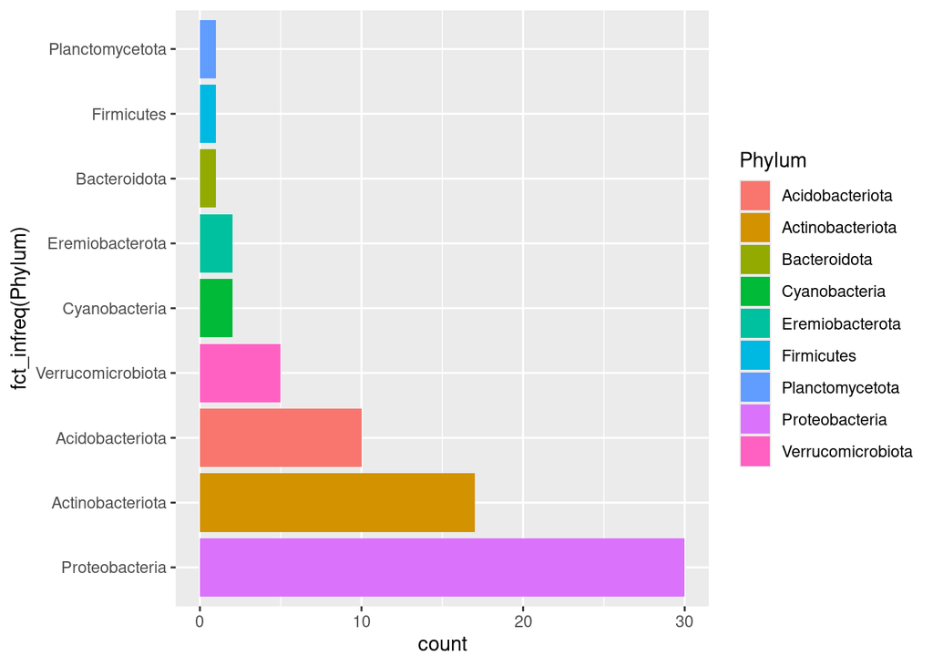

```r
Site_MAGS %>%
ggplot(aes(x = fct_infreq(Phylum))) +
  geom_bar(aes(fill=Phylum)) +
  coord_flip()
```

```r
datatable(NEON_MAGs_Ind_tax %>%
filter(str_detect(`Genome Name`, 'Caribou Creek')) %>%
    count(Phylum, sort = TRUE))
```

|  | Phylum | n |
| --- | --- | --- |
| 1 | Proteobacteria | 30 |
| 2 | Actinobacteriota | 17 |
| 3 | Acidobacteriota | 10 |
| 4 | Verrucomicrobiota | 5 |
| 5 | Cyanobacteria | 2 |
| 6 | Eremiobacterota | 2 |
| 7 | Bacteroidota | 1 |
| 8 | Firmicutes | 1 |
| 9 | Planctomycetota | 1 |

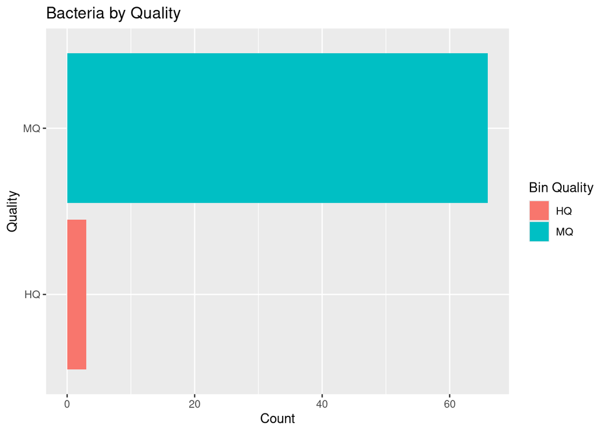

```r
NEON_MAGs_bact_ind %>%
  filter(str_detect(`Site`, 'Caribou Creek')) %>%
ggplot(aes(x = (`Bin Quality`))) +
  labs(title = "Bacteria by Quality", x = "Quality", y = "Count") +
  geom_bar(aes(fill=`Bin Quality`)) +
  coord_flip()
```

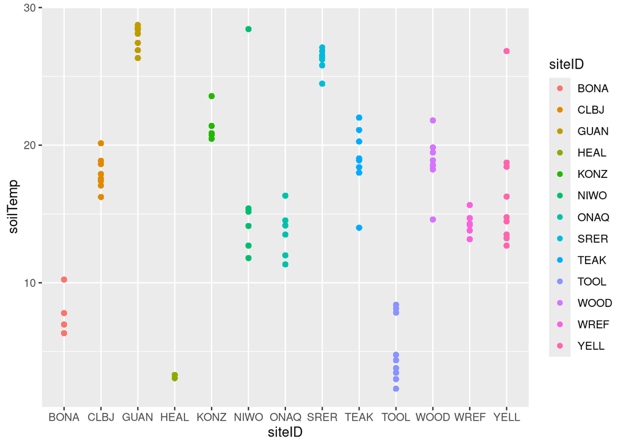

```r
combined_df %>%
  left_join(NEON_MAGs, by = c("siteID" = "Site ID")) %>%
   ggplot(aes(x = `siteID`, y = `soilTemp`)) +
  geom_point(aes(color=siteID))
```

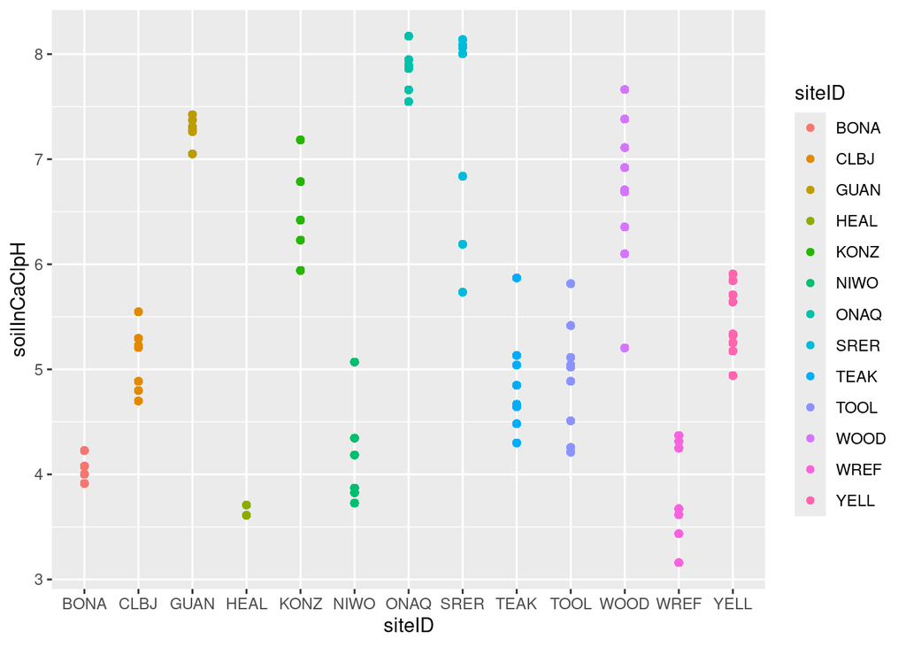

```r
combined_df %>%
  left_join(NEON_MAGs, by = c("siteID" = "Site ID")) %>%
   ggplot(aes(x = `siteID`, y = `soilInCaClpH`)) +
  geom_point(aes(color=siteID))
```

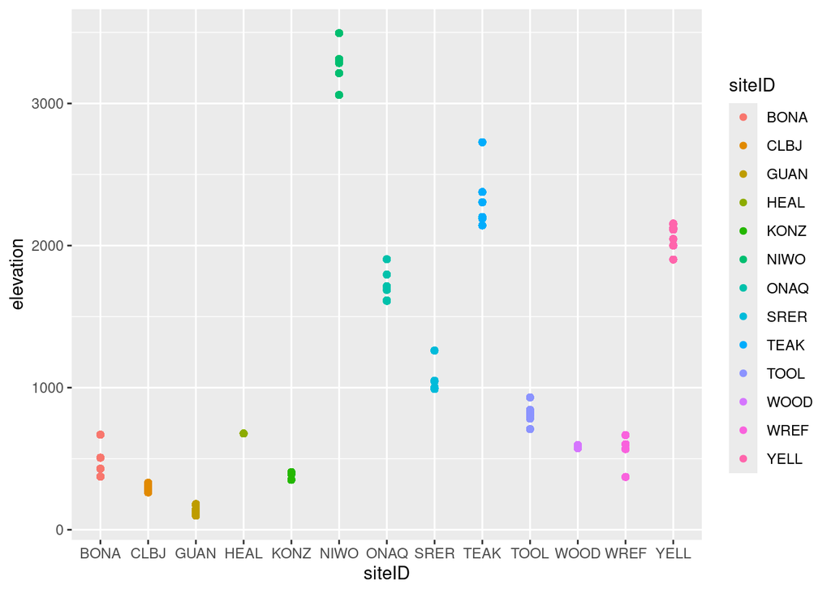

```r
combined_df %>%
  left_join(NEON_MAGs, by = c("siteID" = "Site ID")) %>%
   ggplot(aes(x = `siteID`, y = `elevation`)) +
  geom_point(aes(color=siteID))
```

```r
knitr::include_url("BONASankey.html")
```

[interactive chart not shown]